# customer_segementation

```python
import pandas as pd
import numpy as np
import mysql.connector
import warnings
import math
import seaborn as sns
from sqlalchemy import create_engine
from sklearn.preprocessing import Normalizer
from sklearn.cluster import KMeans, HDBSCAN, OPTICS
from sklearn.metrics import silhouette_score, davies_bouldin_score, calinski_harabasz_score, make_scorer
from matplotlib import pyplot as plt
from mango import Tuner, scheduler
from sklearn.manifold import TSNE
from sklearn.decomposition import PCA
from plotly import express as px
```

## Connect to the database

```python
connection = mysql.connector.connect(host = 'localhost', user = 'root', password = 'root', port = 3306, database='testdb')
engine = create_engine('mysql+mysqlconnector://root:root@localhost:3306/testdb')
cursor = connection.cursor(buffered=True)
cursor.execute("SELECT VERSION()")
cursor.fetchone()
```

```
('8.3.0',)
```

## Extract Tabales

```python
# extract customer table
customer =pd.read_sql('select * from customer', con=engine)
customer.head()
```

|  | Customer_ID | Gender | Age | Profession_Code | Work_Experience | Family_Size | median_annual_wage |
| --- | --- | --- | --- | --- | --- | --- | --- |
| 0 | 1000 | Female | 30 | 35-2010 | 3 | 4 | 30910 |
| 1 | 1001 | Female | 46 | 43-5060 | 9 | 3 | 50630 |
| 2 | 1002 | Male | 28 | 53-7062 | 6 | 5 | 36110 |
| 3 | 1003 | Female | 18 | 31-1100 | 2 | 2 | 31450 |
| 4 | 1004 | Female | 16 | 51-3091 | 1 | 2 | 37790 |

```python
# extract transaction table
transaction = pd.read_sql('select * from transaction', con=engine)
transaction.head()
```

|  | txn_id | Customer_ID | Timestamp | Amount | Transaction_Type |
| --- | --- | --- | --- | --- | --- |
| 0 | 0 | 10061 | 2023-09-28 01:33:49 | 64950.477598 | Deposit |
| 1 | 1 | 9183 | 2023-12-30 17:29:07 | 694.634030 | Withdrawal |
| 2 | 2 | 1442 | 2023-10-24 17:58:40 | 37023.330210 | Deposit |
| 3 | 3 | 7806 | 2024-02-11 01:06:14 | 28538.342907 | Deposit |
| 4 | 4 | 9932 | 2024-01-12 11:42:00 | 1788.829725 | Withdrawal |

```python
# extract BLS table
bls = pd.read_sql('select * from BLS', con=engine)
bls.head()
```

|  | wage_id | AREA | AREA_TITLE | AREA_TYPE | PRIM_STATE | NAICS | NAICS_TITLE | I_GROUP | OWN_CODE | OCC_CODE | ... | H_MEDIAN | H_PCT75 | H_PCT90 | A_PCT10 | A_PCT25 | A_MEDIAN | A_PCT75 | A_PCT90 | ANNUAL | HOURLY |
| --- | --- | --- | --- | --- | --- | --- | --- | --- | --- | --- | --- | --- | --- | --- | --- | --- | --- | --- | --- | --- | --- |
| 0 | 0 | 99 | U.S. | 1 | US | 0 | Cross-industry | cross-industry | 1235 | 00-0000 | ... | 22.26 | 35.32 | 53.03 | 27340 | 33330 | 46310 | 73460 | 110290 | NaN | NaN |
| 1 | 1 | 99 | U.S. | 1 | US | 0 | Cross-industry | cross-industry | 1235 | 11-0000 | ... | 51.62 | 78.71 | 106.03 | 50290 | 75350 | 107360 | 163710 | 220550 | NaN | NaN |
| 2 | 2 | 99 | U.S. | 1 | US | 0 | Cross-industry | cross-industry | 1235 | 11-1000 | ... | 48.02 | 76.96 | 115.00 | 43440 | 62520 | 99890 | 160070 | 239200 | NaN | NaN |
| 3 | 3 | 99 | U.S. | 1 | US | 0 | Cross-industry | cross-industry | 1235 | 11-1010 | ... | 91.12 | 115.00 | 115.00 | 74920 | 122480 | 189520 | 239200 | 239200 | NaN | NaN |
| 4 | 4 | 99 | U.S. | 1 | US | 0 | Cross-industry | cross-industry | 1235 | 11-1011 | ... | 91.12 | 115.00 | 115.00 | 74920 | 122480 | 189520 | 239200 | 239200 | NaN | NaN |

5 rows × 33 columns

```python
# extract account_profile table
account_profile = pd.read_sql('select * from account_profile', con=engine)
account_profile.head()
```

|  | customer_id | card_avg | check_avg | deposit_avg | loan payment_avg | transfer_avg | withdrawal_avg | card_count | check_count | deposit_count | loan payment_count | transfer_count | wihdrawal_count |
| --- | --- | --- | --- | --- | --- | --- | --- | --- | --- | --- | --- | --- | --- |
| 0 | 1000 | 26.47 | 4378.71 | 28869.12 | 12108.41 | 1524.85 | 694.78 | 1 | 2 | 2 | 2 | 1 | 3 |
| 1 | 1001 | 51.53 | 4237.00 | NaN | 28348.91 | 2231.76 | 540.01 | 4 | 2 | 0 | 3 | 4 | 4 |
| 2 | 1002 | NaN | 5117.56 | 27592.44 | 22833.47 | 1642.22 | 692.91 | 0 | 1 | 3 | 3 | 2 | 1 |
| 3 | 1003 | NaN | 5474.51 | NaN | NaN | 1554.03 | 1067.27 | 0 | 2 | 0 | 0 | 1 | 1 |
| 4 | 1004 | 38.21 | NaN | 23236.59 | 14425.75 | 2031.13 | 1032.39 | 6 | 0 | 3 | 3 | 1 | 2 |

### Average of average of lookback days=30

```python
cursor.execute("""
with
    source_table as (
        select
            txn_id, customer_id, timestamp, DATE_FORMAT(timestamp, '%Y-%m') as `year_month`, ROUND(amount, 4) as amount, transaction_type
        from transaction
        order by customer_id, UNIX_TIMESTAMP(timestamp)
    ),
    lbp_txn as (
        select
            a.*, lbp.amount as lbp_amount, lbp.transaction_type as lbp_transaction_type, lbp.timestamp as lbp_timestamp, lbp.txn_id as lbp_txn_id
        from
            source_table a
            join source_table lbp on a.customer_id = lbp.customer_id
            and lbp.timestamp between a.timestamp - interval 30 day and a.timestamp
        order by a.txn_id
    ),
    result_table_2 as (
            select
                    txn_id,
                    customer_id,
                    AVG(case when lbp_transaction_type = 'Card' then lbp_amount end) as card_avg,
                    AVG(case when lbp_transaction_type = 'Check' then lbp_amount end) as check_avg,
                    AVG(case when lbp_transaction_type = 'Deposit' then lbp_amount end) as Deposit_avg,
                    AVG(case when lbp_transaction_type = 'Loan Payment' then lbp_amount end) as `Loan Payment_avg`,
                    AVG(case when lbp_transaction_type = 'Transfer' then lbp_amount end) as Transfer_avg,
                    AVG(case when lbp_transaction_type = 'Withdrawal' then lbp_amount end) as Withdrawal_avg,
                    SUM(case when lbp_transaction_type = 'Card' then 1 else 0 end) as card_count,
                    SUM(case when lbp_transaction_type = 'Check' then 1 else 0 end) as check_count,
                    SUM(case when lbp_transaction_type = 'Deposit' then 1 else 0 end) as Deposit_count,
                    SUM(case when lbp_transaction_type = 'Loan Payment' then 1 else 0 end) as `Loan Payment_count`,
                    SUM(case when lbp_transaction_type = 'Transfer' then 1 else 0 end) as Transfer_count,
                    SUM(case when lbp_transaction_type = 'Withdrawal' then 1 else 0 end) as Withdrawal_count
            from
                lbp_txn
            group by
                txn_id, customer_id
    )
    select
    a.customer_id as customer_id,
    AVG(card_avg) as card_monthly_avg,
    AVG(check_avg) as check_monthly_avg,
    AVG(Deposit_avg) as Deposit_monthly_avg,
    AVG(`Loan Payment_avg`) as `Loan Payment_monthly_avg`,
    AVG(Transfer_avg) as Transfer_monthly_avg,
    AVG(Withdrawal_avg) as Withdrawal_monthly_avg,
    AVG(card_count) as card_monthly_count_avg,
    AVG(check_count) as check_monthly_count_avg,
    AVG(Deposit_count) as Deposit_monthly_count_avg,
    AVG(`Loan Payment_count`) as `Loan Payment_monthly_count_avg`,
    AVG(Transfer_count) as Transfer_monthly_count_avg,
    AVG(Withdrawal_count) as Withdrawal_monthly_count_avg
    from result_table_2 a
    group by a.customer_id
    order by a.customer_id;

""")

lbp_txn = pd.DataFrame(cursor.fetchall(), columns=cursor.column_names)
lbp_txn.head()
```

|  | customer_id | card_monthly_avg | check_monthly_avg | Deposit_monthly_avg | Loan Payment_monthly_avg | Transfer_monthly_avg | Withdrawal_monthly_avg | card_monthly_count_avg | check_monthly_count_avg | Deposit_monthly_count_avg | Loan Payment_monthly_count_avg | Transfer_monthly_count_avg | Withdrawal_monthly_count_avg |
| --- | --- | --- | --- | --- | --- | --- | --- | --- | --- | --- | --- | --- | --- |
| 0 | 1000 | 26.467100 | 3467.027540 | 34562.745600 | 11501.541400 | 1524.846000 | 700.624030 | 0.1818 | 0.4545 | 0.4545 | 0.6364 | 0.0909 | 0.9091 |
| 1 | 1001 | 48.446956 | 4237.004550 | NaN | 32005.647125 | 2018.548818 | 566.694123 | 0.7647 | 0.4706 | 0.0000 | 0.5882 | 1.0588 | 0.9412 |
| 2 | 1002 | NaN | 5117.557300 | 29283.843167 | 22465.321025 | 2027.734875 | 692.912700 | 0.0000 | 0.3000 | 0.7000 | 0.6000 | 0.3000 | 0.2000 |
| 3 | 1003 | NaN | 6686.745925 | NaN | NaN | 1554.027000 | 1067.274700 | 0.0000 | 1.0000 | 0.0000 | 0.0000 | 0.2500 | 0.5000 |
| 4 | 1004 | 38.045262 | NaN | 22805.543736 | 14111.396580 | 2031.130900 | 1124.469600 | 1.0000 | 0.0000 | 0.6667 | 0.5333 | 0.2000 | 0.4667 |

```python
cursor.close()
connection.close()
```

## Clean the data

### Customer Table

```python
customer.head()
```

|  | Customer_ID | Gender | Age | Profession_Code | Work_Experience | Family_Size | median_annual_wage |
| --- | --- | --- | --- | --- | --- | --- | --- |
| 0 | 1000 | Female | 30 | 35-2010 | 3 | 4 | 30910 |
| 1 | 1001 | Female | 46 | 43-5060 | 9 | 3 | 50630 |
| 2 | 1002 | Male | 28 | 53-7062 | 6 | 5 | 36110 |
| 3 | 1003 | Female | 18 | 31-1100 | 2 | 2 | 31450 |
| 4 | 1004 | Female | 16 | 51-3091 | 1 | 2 | 37790 |

```python
customer.info()
```

```
<class 'pandas.core.frame.DataFrame'>
RangeIndex: 10000 entries, 0 to 9999
Data columns (total 7 columns):
 #   Column              Non-Null Count  Dtype
---  ------              --------------  -----
 0   Customer_ID         10000 non-null  int64
 1   Gender              10000 non-null  object
 2   Age                 10000 non-null  int64
 3   Profession_Code     10000 non-null  object
 4   Work_Experience     10000 non-null  int64
 5   Family_Size         10000 non-null  int64
 6   median_annual_wage  10000 non-null  object
dtypes: int64(4), object(3)
memory usage: 547.0+ KB
```

```python
# change the data type of the column
customer['median_annual_wage'] = customer['median_annual_wage'].astype('float')
customer.info()
```

```
<class 'pandas.core.frame.DataFrame'>
RangeIndex: 10000 entries, 0 to 9999
Data columns (total 7 columns):
 #   Column              Non-Null Count  Dtype
---  ------              --------------  -----
 0   Customer_ID         10000 non-null  int64
 1   Gender              10000 non-null  object
 2   Age                 10000 non-null  int64
 3   Profession_Code     10000 non-null  object
 4   Work_Experience     10000 non-null  int64
 5   Family_Size         10000 non-null  int64
 6   median_annual_wage  9998 non-null   float64
dtypes: float64(1), int64(4), object(2)
memory usage: 547.0+ KB
```

### lbp_txn table

```python
lbp_txn.head()
```

|  | customer_id | card_monthly_avg | check_monthly_avg | Deposit_monthly_avg | Loan Payment_monthly_avg | Transfer_monthly_avg | Withdrawal_monthly_avg | card_monthly_count_avg | check_monthly_count_avg | Deposit_monthly_count_avg | Loan Payment_monthly_count_avg | Transfer_monthly_count_avg | Withdrawal_monthly_count_avg |
| --- | --- | --- | --- | --- | --- | --- | --- | --- | --- | --- | --- | --- | --- |
| 0 | 1000 | 26.467100 | 3467.027540 | 34562.745600 | 11501.541400 | 1524.846000 | 700.624030 | 0.1818 | 0.4545 | 0.4545 | 0.6364 | 0.0909 | 0.9091 |
| 1 | 1001 | 48.446956 | 4237.004550 | NaN | 32005.647125 | 2018.548818 | 566.694123 | 0.7647 | 0.4706 | 0.0000 | 0.5882 | 1.0588 | 0.9412 |
| 2 | 1002 | NaN | 5117.557300 | 29283.843167 | 22465.321025 | 2027.734875 | 692.912700 | 0.0000 | 0.3000 | 0.7000 | 0.6000 | 0.3000 | 0.2000 |
| 3 | 1003 | NaN | 6686.745925 | NaN | NaN | 1554.027000 | 1067.274700 | 0.0000 | 1.0000 | 0.0000 | 0.0000 | 0.2500 | 0.5000 |
| 4 | 1004 | 38.045262 | NaN | 22805.543736 | 14111.396580 | 2031.130900 | 1124.469600 | 1.0000 | 0.0000 | 0.6667 | 0.5333 | 0.2000 | 0.4667 |

```python
# replace the null value with 0
lbp_txn.fillna(0, inplace=True)
lbp_txn.head()
```

|  | customer_id | card_monthly_avg | check_monthly_avg | Deposit_monthly_avg | Loan Payment_monthly_avg | Transfer_monthly_avg | Withdrawal_monthly_avg | card_monthly_count_avg | check_monthly_count_avg | Deposit_monthly_count_avg | Loan Payment_monthly_count_avg | Transfer_monthly_count_avg | Withdrawal_monthly_count_avg |
| --- | --- | --- | --- | --- | --- | --- | --- | --- | --- | --- | --- | --- | --- |
| 0 | 1000 | 26.467100 | 3467.027540 | 34562.745600 | 11501.541400 | 1524.846000 | 700.624030 | 0.1818 | 0.4545 | 0.4545 | 0.6364 | 0.0909 | 0.9091 |
| 1 | 1001 | 48.446956 | 4237.004550 | 0.000000 | 32005.647125 | 2018.548818 | 566.694123 | 0.7647 | 0.4706 | 0.0000 | 0.5882 | 1.0588 | 0.9412 |
| 2 | 1002 | 0.000000 | 5117.557300 | 29283.843167 | 22465.321025 | 2027.734875 | 692.912700 | 0.0000 | 0.3000 | 0.7000 | 0.6000 | 0.3000 | 0.2000 |
| 3 | 1003 | 0.000000 | 6686.745925 | 0.000000 | 0.000000 | 1554.027000 | 1067.274700 | 0.0000 | 1.0000 | 0.0000 | 0.0000 | 0.2500 | 0.5000 |
| 4 | 1004 | 38.045262 | 0.000000 | 22805.543736 | 14111.396580 | 2031.130900 | 1124.469600 | 1.0000 | 0.0000 | 0.6667 | 0.5333 | 0.2000 | 0.4667 |

```python
lbp_txn.info()
```

```
<class 'pandas.core.frame.DataFrame'>
RangeIndex: 10000 entries, 0 to 9999
Data columns (total 13 columns):
 #   Column                          Non-Null Count  Dtype
---  ------                          --------------  -----
 0   customer_id                     10000 non-null  int64
 1   card_monthly_avg                10000 non-null  float64
 2   check_monthly_avg               10000 non-null  float64
 3   Deposit_monthly_avg             10000 non-null  float64
 4   Loan Payment_monthly_avg        10000 non-null  float64
 5   Transfer_monthly_avg            10000 non-null  float64
 6   Withdrawal_monthly_avg          10000 non-null  float64
 7   card_monthly_count_avg          10000 non-null  object
 8   check_monthly_count_avg         10000 non-null  object
 9   Deposit_monthly_count_avg       10000 non-null  object
 10  Loan Payment_monthly_count_avg  10000 non-null  object
 11  Transfer_monthly_count_avg      10000 non-null  object
 12  Withdrawal_monthly_count_avg    10000 non-null  object
dtypes: float64(6), int64(1), object(6)
memory usage: 1015.8+ KB
```

```python
# change object column to float
for col in lbp_txn.columns[1:]:
    lbp_txn[col] = lbp_txn[col].astype('float')
lbp_txn.info()
```

```
<class 'pandas.core.frame.DataFrame'>
RangeIndex: 10000 entries, 0 to 9999
Data columns (total 13 columns):
 #   Column                          Non-Null Count  Dtype
---  ------                          --------------  -----
 0   customer_id                     10000 non-null  int64
 1   card_monthly_avg                10000 non-null  float64
 2   check_monthly_avg               10000 non-null  float64
 3   Deposit_monthly_avg             10000 non-null  float64
 4   Loan Payment_monthly_avg        10000 non-null  float64
 5   Transfer_monthly_avg            10000 non-null  float64
 6   Withdrawal_monthly_avg          10000 non-null  float64
 7   card_monthly_count_avg          10000 non-null  float64
 8   check_monthly_count_avg         10000 non-null  float64
 9   Deposit_monthly_count_avg       10000 non-null  float64
 10  Loan Payment_monthly_count_avg  10000 non-null  float64
 11  Transfer_monthly_count_avg      10000 non-null  float64
 12  Withdrawal_monthly_count_avg    10000 non-null  float64
dtypes: float64(12), int64(1)
memory usage: 1015.8 KB
```

### account profile table

```python
account_profile
```

|  | customer_id | card_avg | check_avg | deposit_avg | loan payment_avg | transfer_avg | withdrawal_avg | card_count | check_count | deposit_count | loan payment_count | transfer_count | wihdrawal_count |
| --- | --- | --- | --- | --- | --- | --- | --- | --- | --- | --- | --- | --- | --- |
| 0 | 1000 | 26.47 | 4378.71 | 28869.12 | 12108.41 | 1524.85 | 694.78 | 1 | 2 | 2 | 2 | 1 | 3 |
| 1 | 1001 | 51.53 | 4237.00 | NaN | 28348.91 | 2231.76 | 540.01 | 4 | 2 | 0 | 3 | 4 | 4 |
| 2 | 1002 | NaN | 5117.56 | 27592.44 | 22833.47 | 1642.22 | 692.91 | 0 | 1 | 3 | 3 | 2 | 1 |
| 3 | 1003 | NaN | 5474.51 | NaN | NaN | 1554.03 | 1067.27 | 0 | 2 | 0 | 0 | 1 | 1 |
| 4 | 1004 | 38.21 | NaN | 23236.59 | 14425.75 | 2031.13 | 1032.39 | 6 | 0 | 3 | 3 | 1 | 2 |
| ... | ... | ... | ... | ... | ... | ... | ... | ... | ... | ... | ... | ... | ... |
| 9995 | 10995 | 33.20 | NaN | NaN | 14913.75 | 2468.82 | 587.00 | 1 | 0 | 0 | 1 | 3 | 3 |
| 9996 | 10996 | 105.45 | NaN | 46180.04 | 29398.99 | 1804.69 | 407.88 | 2 | 0 | 1 | 3 | 1 | 1 |
| 9997 | 10997 | 84.71 | 5107.67 | 40858.35 | 25356.89 | 1284.74 | NaN | 1 | 1 | 5 | 1 | 4 | 0 |
| 9998 | 10998 | 50.77 | 5206.95 | 27874.57 | 23206.13 | 3029.61 | NaN | 3 | 1 | 2 | 1 | 1 | 0 |
| 9999 | 10999 | 37.89 | 11104.57 | 48534.17 | 18573.65 | 3316.20 | 757.11 | 2 | 2 | 2 | 2 | 1 | 2 |

10000 rows × 13 columns

#### Compare with account profile table and the customer monthly average table, the account profile table cannot reflect the customer's pattern, because it just simply group by the customer_id and calculate the average and count of transactions per customer. However, when time passes, the count of transactions per customer will increase, and the average of transactions amount will fail to reflect the customer's pattern. The first step of creating the customer average of average table is calculate the average and count for each transaction by looking back 30 days. The second step is to calculate the average group by customer_id. The average and the count can fully reflect the customer's pattern compare with the account profile table and will make each customer have a unique pattern.

```python
customer_df = pd.merge(customer, lbp_txn, left_on='Customer_ID', right_on='customer_id', how='left')
customer_df = customer_df.drop(columns=['customer_id'])
customer_df
```

|  | Customer_ID | Gender | Age | Profession_Code | Work_Experience | Family_Size | median_annual_wage | card_monthly_avg | check_monthly_avg | Deposit_monthly_avg | Loan Payment_monthly_avg | Transfer_monthly_avg | Withdrawal_monthly_avg | card_monthly_count_avg | check_monthly_count_avg | Deposit_monthly_count_avg | Loan Payment_monthly_count_avg | Transfer_monthly_count_avg | Withdrawal_monthly_count_avg |
| --- | --- | --- | --- | --- | --- | --- | --- | --- | --- | --- | --- | --- | --- | --- | --- | --- | --- | --- | --- |
| 0 | 1000 | Female | 30 | 35-2010 | 3 | 4 | 30910.0 | 26.467100 | 3467.027540 | 34562.745600 | 11501.541400 | 1524.846000 | 700.624030 | 0.1818 | 0.4545 | 0.4545 | 0.6364 | 0.0909 | 0.9091 |
| 1 | 1001 | Female | 46 | 43-5060 | 9 | 3 | 50630.0 | 48.446956 | 4237.004550 | 0.000000 | 32005.647125 | 2018.548818 | 566.694123 | 0.7647 | 0.4706 | 0.0000 | 0.5882 | 1.0588 | 0.9412 |
| 2 | 1002 | Male | 28 | 53-7062 | 6 | 5 | 36110.0 | 0.000000 | 5117.557300 | 29283.843167 | 22465.321025 | 2027.734875 | 692.912700 | 0.0000 | 0.3000 | 0.7000 | 0.6000 | 0.3000 | 0.2000 |
| 3 | 1003 | Female | 18 | 31-1100 | 2 | 2 | 31450.0 | 0.000000 | 6686.745925 | 0.000000 | 0.000000 | 1554.027000 | 1067.274700 | 0.0000 | 1.0000 | 0.0000 | 0.0000 | 0.2500 | 0.5000 |
| 4 | 1004 | Female | 16 | 51-3091 | 1 | 2 | 37790.0 | 38.045262 | 0.000000 | 22805.543736 | 14111.396580 | 2031.130900 | 1124.469600 | 1.0000 | 0.0000 | 0.6667 | 0.5333 | 0.2000 | 0.4667 |
| ... | ... | ... | ... | ... | ... | ... | ... | ... | ... | ... | ... | ... | ... | ... | ... | ... | ... | ... | ... |
| 9995 | 10995 | Male | 32 | 53-7062 | 6 | 3 | 36110.0 | 33.196400 | 0.000000 | 0.000000 | 14913.754300 | 2504.400258 | 591.165900 | 0.2500 | 0.0000 | 0.0000 | 0.1250 | 0.8750 | 1.0000 |
| 9996 | 10996 | Male | 21 | 41-0000 | 0 | 5 | 35290.0 | 72.489450 | 0.000000 | 46180.036900 | 34283.615478 | 1804.694300 | 407.880200 | 0.3750 | 0.0000 | 0.3750 | 0.7500 | 0.2500 | 0.1250 |
| 9997 | 10997 | Female | 23 | 41-2000 | 5 | 1 | 29660.0 | 84.705200 | 5107.672800 | 41515.278744 | 25356.892000 | 1262.464967 | 0.000000 | 0.0833 | 0.1667 | 1.0833 | 0.1667 | 0.8333 | 0.0000 |
| 9998 | 10998 | Female | 48 | 15-1252 | 21 | 4 | 127260.0 | 54.843460 | 5206.945000 | 26699.792200 | 23206.125000 | 3029.610100 | 0.000000 | 0.8750 | 0.2500 | 0.3750 | 0.3750 | 0.3750 | 0.0000 |
| 9999 | 10999 | Female | 43 | 13-2010 | 21 | 4 | 78000.0 | 39.665000 | 11742.832200 | 48534.167200 | 17119.035900 | 3316.201300 | 685.815150 | 0.3636 | 0.2727 | 0.3636 | 0.5455 | 0.0909 | 0.3636 |

10000 rows × 19 columns

```python
customer_df.isna().sum()
```

```
Customer_ID                       0
Gender                            0
Age                               0
Profession_Code                   0
Work_Experience                   0
Family_Size                       0
median_annual_wage                2
card_monthly_avg                  0
check_monthly_avg                 0
Deposit_monthly_avg               0
Loan Payment_monthly_avg          0
Transfer_monthly_avg              0
Withdrawal_monthly_avg            0
card_monthly_count_avg            0
check_monthly_count_avg           0
Deposit_monthly_count_avg         0
Loan Payment_monthly_count_avg    0
Transfer_monthly_count_avg        0
Withdrawal_monthly_count_avg      0
dtype: int64
```

```python
customer_df[customer_df['median_annual_wage'].isna()]
```

|  | Customer_ID | Gender | Age | Profession_Code | Work_Experience | Family_Size | median_annual_wage | card_monthly_avg | check_monthly_avg | Deposit_monthly_avg | Loan Payment_monthly_avg | Transfer_monthly_avg | Withdrawal_monthly_avg | card_monthly_count_avg | check_monthly_count_avg | Deposit_monthly_count_avg | Loan Payment_monthly_count_avg | Transfer_monthly_count_avg | Withdrawal_monthly_count_avg |
| --- | --- | --- | --- | --- | --- | --- | --- | --- | --- | --- | --- | --- | --- | --- | --- | --- | --- | --- | --- |
| 305 | 1305 | Male | 42 | 27-2040 | 9 | 2 | NaN | 26.69818 | 0.0000 | 19802.034038 | 11583.2543 | 2247.82870 | 796.919100 | 0.5 | 0.0 | 0.5 | 0.5 | 0.3 | 0.2 |
| 628 | 1628 | Male | 37 | 27-2040 | 10 | 5 | NaN | 0.00000 | 4078.8717 | 50991.402200 | 20569.2073 | 1585.27362 | 1195.579475 | 0.0 | 0.4 | 0.3 | 0.3 | 0.5 | 0.5 |

```python
# to handle the missin values in the money-related columns, replace the missing values to -1 in order to distinguish them from the other values (including 0)
customer_df.fillna(-1, inplace=True)
customer_df.isna().sum()
```

```
Customer_ID                       0
Gender                            0
Age                               0
Profession_Code                   0
Work_Experience                   0
Family_Size                       0
median_annual_wage                0
card_monthly_avg                  0
check_monthly_avg                 0
Deposit_monthly_avg               0
Loan Payment_monthly_avg          0
Transfer_monthly_avg              0
Withdrawal_monthly_avg            0
card_monthly_count_avg            0
check_monthly_count_avg           0
Deposit_monthly_count_avg         0
Loan Payment_monthly_count_avg    0
Transfer_monthly_count_avg        0
Withdrawal_monthly_count_avg      0
dtype: int64
```

```python
customer_df.info()
```

```
<class 'pandas.core.frame.DataFrame'>
RangeIndex: 10000 entries, 0 to 9999
Data columns (total 19 columns):
 #   Column                          Non-Null Count  Dtype
---  ------                          --------------  -----
 0   Customer_ID                     10000 non-null  int64
 1   Gender                          10000 non-null  object
 2   Age                             10000 non-null  int64
 3   Profession_Code                 10000 non-null  object
 4   Work_Experience                 10000 non-null  int64
 5   Family_Size                     10000 non-null  int64
 6   median_annual_wage              10000 non-null  float64
 7   card_monthly_avg                10000 non-null  float64
 8   check_monthly_avg               10000 non-null  float64
 9   Deposit_monthly_avg             10000 non-null  float64
 10  Loan Payment_monthly_avg        10000 non-null  float64
 11  Transfer_monthly_avg            10000 non-null  float64
 12  Withdrawal_monthly_avg          10000 non-null  float64
 13  card_monthly_count_avg          10000 non-null  float64
 14  check_monthly_count_avg         10000 non-null  float64
 15  Deposit_monthly_count_avg       10000 non-null  float64
 16  Loan Payment_monthly_count_avg  10000 non-null  float64
 17  Transfer_monthly_count_avg      10000 non-null  float64
 18  Withdrawal_monthly_count_avg    10000 non-null  float64
dtypes: float64(13), int64(4), object(2)
memory usage: 1.4+ MB
```

```python
bls.info()
```

```
<class 'pandas.core.frame.DataFrame'>
RangeIndex: 1395 entries, 0 to 1394
Data columns (total 33 columns):
 #   Column        Non-Null Count  Dtype
---  ------        --------------  -----
 0   wage_id       1395 non-null   int64
 1   AREA          1395 non-null   int64
 2   AREA_TITLE    1395 non-null   object
 3   AREA_TYPE     1395 non-null   int64
 4   PRIM_STATE    1395 non-null   object
 5   NAICS         1395 non-null   int64
 6   NAICS_TITLE   1395 non-null   object
 7   I_GROUP       1395 non-null   object
 8   OWN_CODE      1395 non-null   int64
 9   OCC_CODE      1395 non-null   object
```

[output cut: 25 more lines]

```python
# join the customer_df with the slb table drop duplicate columns
customer_df = pd.merge(customer_df, bls, left_on='Profession_Code', right_on='OCC_CODE', how='left')
customer_df = customer_df.drop(columns=['OCC_CODE','A_MEDIAN','wage_id'])
customer_df
```

|  | Customer_ID | Gender | Age | Profession_Code | Work_Experience | Family_Size | median_annual_wage | card_monthly_avg | check_monthly_avg | Deposit_monthly_avg | ... | H_PCT25 | H_MEDIAN | H_PCT75 | H_PCT90 | A_PCT10 | A_PCT25 | A_PCT75 | A_PCT90 | ANNUAL | HOURLY |
| --- | --- | --- | --- | --- | --- | --- | --- | --- | --- | --- | --- | --- | --- | --- | --- | --- | --- | --- | --- | --- | --- |
| 0 | 1000 | Female | 30 | 35-2010 | 3 | 4 | 30910.0 | 26.467100 | 3467.027540 | 34562.745600 | ... | 12.93 | 14.86 | 17.48 | 20.56 | 21990 | 26900 | 36360 | 42770 | NaN | NaN |
| 1 | 1001 | Female | 46 | 43-5060 | 9 | 3 | 50630.0 | 48.446956 | 4237.004550 | 0.000000 | ... | 19.62 | 24.34 | 30.96 | 38.1 | 35030 | 40800 | 64400 | 79260 | NaN | NaN |
| 2 | 1002 | Male | 28 | 53-7062 | 6 | 5 | 36110.0 | 0.000000 | 5117.557300 | 29283.843167 | ... | 14.97 | 17.36 | 20.42 | 23.35 | 27610 | 31130 | 42470 | 48560 | NaN | NaN |
| 3 | 1003 | Female | 18 | 31-1100 | 2 | 2 | 31450.0 | 0.000000 | 6686.745925 | 0.000000 | ... | 13.59 | 15.12 | 17.36 | 19.64 | 23210 | 28280 | 36110 | 40850 | NaN | NaN |
| 4 | 1004 | Female | 16 | 51-3091 | 1 | 2 | 37790.0 | 38.045262 | 0.000000 | 22805.543736 | ... | 15.1 | 18.17 | 22.39 | 26.49 | 27040 | 31400 | 46560 | 55110 | NaN | NaN |
| ... | ... | ... | ... | ... | ... | ... | ... | ... | ... | ... | ... | ... | ... | ... | ... | ... | ... | ... | ... | ... | ... |
| 9995 | 10995 | Male | 32 | 53-7062 | 6 | 3 | 36110.0 | 33.196400 | 0.000000 | 0.000000 | ... | 14.97 | 17.36 | 20.42 | 23.35 | 27610 | 31130 | 42470 | 48560 | NaN | NaN |
| 9996 | 10996 | Male | 21 | 41-0000 | 0 | 5 | 35290.0 | 72.489450 | 0.000000 | 46180.036900 | ... | 13.61 | 16.96 | 27.16 | 45.21 | 23180 | 28310 | 56480 | 94040 | NaN | NaN |
| 9997 | 10997 | Female | 23 | 41-2000 | 5 | 1 | 29660.0 | 84.705200 | 5107.672800 | 41515.278744 | ... | 12.43 | 14.26 | 16.8 | 21.12 | 22090 | 25850 | 34940 | 43920 | NaN | NaN |
| 9998 | 10998 | Female | 48 | 15-1252 | 21 | 4 | 127260.0 | 54.843460 | 5206.945000 | 26699.792200 | ... | 46.54 | 61.18 | 77.64 | 95.24 | 71280 | 96790 | 161480 | 198100 | NaN | NaN |
| 9999 | 10999 | Female | 43 | 13-2010 | 21 | 4 | 78000.0 | 39.665000 | 11742.832200 | 48534.167200 | ... | 29.29 | 37.5 | 48.63 | 63.79 | 48560 | 60920 | 101150 | 132690 | NaN | NaN |

10000 rows × 49 columns

```python
customer_df.isna().sum()
```

```
Customer_ID                           0
Gender                                0
Age                                   0
Profession_Code                       0
Work_Experience                       0
Family_Size                           0
median_annual_wage                    0
card_monthly_avg                      0
check_monthly_avg                     0
Deposit_monthly_avg                   0
Loan Payment_monthly_avg              0
Transfer_monthly_avg                  0
Withdrawal_monthly_avg                0
card_monthly_count_avg                0
check_monthly_count_avg               0
Deposit_monthly_count_avg             0
Loan Payment_monthly_count_avg        0
Transfer_monthly_count_avg            0
Withdrawal_monthly_count_avg          0
AREA                                  0
AREA_TITLE                            0
AREA_TYPE                             0
PRIM_STATE                            0
NAICS                                 0
NAICS_TITLE                           0
I_GROUP                               0
OWN_CODE                              0
OCC_TITLE                             0
O_GROUP                               0
TOT_EMP                               0
EMP_PRSE                              0
JOBS_1000                         10000
LOC_QUOTIENT                      10000
PCT_TOTAL                         10000
PCT_RPT                           10000
H_MEAN                                0
A_MEAN                                0
MEAN_PRSE                             0
H_PCT10                               0
H_PCT25                               0
H_MEDIAN                              0
H_PCT75                               0
H_PCT90                               0
A_PCT10                               0
A_PCT25                               0
A_PCT75                               0
A_PCT90                               0
ANNUAL                             9669
HOURLY                             9998
dtype: int64
```

```python
# JOBS_1000, LOC_QUOTIENT, PCT_TOTAL, and PCT_RPT are all empty columns, so we can drop them
customer_df = customer_df.drop(columns=['JOBS_1000','LOC_QUOTIENT','PCT_TOTAL','PCT_RPT'])
customer_df
```

|  | Customer_ID | Gender | Age | Profession_Code | Work_Experience | Family_Size | median_annual_wage | card_monthly_avg | check_monthly_avg | Deposit_monthly_avg | ... | H_PCT25 | H_MEDIAN | H_PCT75 | H_PCT90 | A_PCT10 | A_PCT25 | A_PCT75 | A_PCT90 | ANNUAL | HOURLY |
| --- | --- | --- | --- | --- | --- | --- | --- | --- | --- | --- | --- | --- | --- | --- | --- | --- | --- | --- | --- | --- | --- |
| 0 | 1000 | Female | 30 | 35-2010 | 3 | 4 | 30910.0 | 26.467100 | 3467.027540 | 34562.745600 | ... | 12.93 | 14.86 | 17.48 | 20.56 | 21990 | 26900 | 36360 | 42770 | NaN | NaN |
| 1 | 1001 | Female | 46 | 43-5060 | 9 | 3 | 50630.0 | 48.446956 | 4237.004550 | 0.000000 | ... | 19.62 | 24.34 | 30.96 | 38.1 | 35030 | 40800 | 64400 | 79260 | NaN | NaN |
| 2 | 1002 | Male | 28 | 53-7062 | 6 | 5 | 36110.0 | 0.000000 | 5117.557300 | 29283.843167 | ... | 14.97 | 17.36 | 20.42 | 23.35 | 27610 | 31130 | 42470 | 48560 | NaN | NaN |
| 3 | 1003 | Female | 18 | 31-1100 | 2 | 2 | 31450.0 | 0.000000 | 6686.745925 | 0.000000 | ... | 13.59 | 15.12 | 17.36 | 19.64 | 23210 | 28280 | 36110 | 40850 | NaN | NaN |
| 4 | 1004 | Female | 16 | 51-3091 | 1 | 2 | 37790.0 | 38.045262 | 0.000000 | 22805.543736 | ... | 15.1 | 18.17 | 22.39 | 26.49 | 27040 | 31400 | 46560 | 55110 | NaN | NaN |
| ... | ... | ... | ... | ... | ... | ... | ... | ... | ... | ... | ... | ... | ... | ... | ... | ... | ... | ... | ... | ... | ... |
| 9995 | 10995 | Male | 32 | 53-7062 | 6 | 3 | 36110.0 | 33.196400 | 0.000000 | 0.000000 | ... | 14.97 | 17.36 | 20.42 | 23.35 | 27610 | 31130 | 42470 | 48560 | NaN | NaN |
| 9996 | 10996 | Male | 21 | 41-0000 | 0 | 5 | 35290.0 | 72.489450 | 0.000000 | 46180.036900 | ... | 13.61 | 16.96 | 27.16 | 45.21 | 23180 | 28310 | 56480 | 94040 | NaN | NaN |
| 9997 | 10997 | Female | 23 | 41-2000 | 5 | 1 | 29660.0 | 84.705200 | 5107.672800 | 41515.278744 | ... | 12.43 | 14.26 | 16.8 | 21.12 | 22090 | 25850 | 34940 | 43920 | NaN | NaN |
| 9998 | 10998 | Female | 48 | 15-1252 | 21 | 4 | 127260.0 | 54.843460 | 5206.945000 | 26699.792200 | ... | 46.54 | 61.18 | 77.64 | 95.24 | 71280 | 96790 | 161480 | 198100 | NaN | NaN |
| 9999 | 10999 | Female | 43 | 13-2010 | 21 | 4 | 78000.0 | 39.665000 | 11742.832200 | 48534.167200 | ... | 29.29 | 37.5 | 48.63 | 63.79 | 48560 | 60920 | 101150 | 132690 | NaN | NaN |

10000 rows × 45 columns

```python
customer_df.isna().sum()
```

```
Customer_ID                          0
Gender                               0
Age                                  0
Profession_Code                      0
Work_Experience                      0
Family_Size                          0
median_annual_wage                   0
card_monthly_avg                     0
check_monthly_avg                    0
Deposit_monthly_avg                  0
Loan Payment_monthly_avg             0
Transfer_monthly_avg                 0
Withdrawal_monthly_avg               0
card_monthly_count_avg               0
check_monthly_count_avg              0
Deposit_monthly_count_avg            0
Loan Payment_monthly_count_avg       0
Transfer_monthly_count_avg           0
Withdrawal_monthly_count_avg         0
AREA                                 0
AREA_TITLE                           0
AREA_TYPE                            0
PRIM_STATE                           0
NAICS                                0
NAICS_TITLE                          0
I_GROUP                              0
OWN_CODE                             0
OCC_TITLE                            0
O_GROUP                              0
TOT_EMP                              0
EMP_PRSE                             0
H_MEAN                               0
A_MEAN                               0
MEAN_PRSE                            0
H_PCT10                              0
H_PCT25                              0
H_MEDIAN                             0
H_PCT75                              0
H_PCT90                              0
A_PCT10                              0
A_PCT25                              0
A_PCT75                              0
A_PCT90                              0
ANNUAL                            9669
HOURLY                            9998
dtype: int64
```

- annual - Contains "TRUE" if only annual wages are released. The OEWS program releases only annual wages for some occupations that typically work fewer than 2,080 hours per year, but are paid on an annual basis, such as teachers, pilots, and athletes.
- hourly - Contains "TRUE" if only hourly wages are released. The OEWS program releases only hourly wages for some occupations that typically work fewer than 2,080 hours per year and are paid on an hourly basis, such as actors, dancers, and musicians and singers.

```python
print(customer_df['ANNUAL'].unique())
print(customer_df['HOURLY'].unique())
```

```
[nan  1.]
[nan  1.]
```

```python
# replace nan in the ANNUAL and HOURLY columns with 0 as FALSE
customer_df['ANNUAL'] = customer_df['ANNUAL'].fillna(0)
customer_df['HOURLY'] = customer_df['HOURLY'].fillna(0)
customer_df
```

|  | Customer_ID | Gender | Age | Profession_Code | Work_Experience | Family_Size | median_annual_wage | card_monthly_avg | check_monthly_avg | Deposit_monthly_avg | ... | H_PCT25 | H_MEDIAN | H_PCT75 | H_PCT90 | A_PCT10 | A_PCT25 | A_PCT75 | A_PCT90 | ANNUAL | HOURLY |
| --- | --- | --- | --- | --- | --- | --- | --- | --- | --- | --- | --- | --- | --- | --- | --- | --- | --- | --- | --- | --- | --- |
| 0 | 1000 | Female | 30 | 35-2010 | 3 | 4 | 30910.0 | 26.467100 | 3467.027540 | 34562.745600 | ... | 12.93 | 14.86 | 17.48 | 20.56 | 21990 | 26900 | 36360 | 42770 | 0.0 | 0.0 |
| 1 | 1001 | Female | 46 | 43-5060 | 9 | 3 | 50630.0 | 48.446956 | 4237.004550 | 0.000000 | ... | 19.62 | 24.34 | 30.96 | 38.1 | 35030 | 40800 | 64400 | 79260 | 0.0 | 0.0 |
| 2 | 1002 | Male | 28 | 53-7062 | 6 | 5 | 36110.0 | 0.000000 | 5117.557300 | 29283.843167 | ... | 14.97 | 17.36 | 20.42 | 23.35 | 27610 | 31130 | 42470 | 48560 | 0.0 | 0.0 |
| 3 | 1003 | Female | 18 | 31-1100 | 2 | 2 | 31450.0 | 0.000000 | 6686.745925 | 0.000000 | ... | 13.59 | 15.12 | 17.36 | 19.64 | 23210 | 28280 | 36110 | 40850 | 0.0 | 0.0 |
| 4 | 1004 | Female | 16 | 51-3091 | 1 | 2 | 37790.0 | 38.045262 | 0.000000 | 22805.543736 | ... | 15.1 | 18.17 | 22.39 | 26.49 | 27040 | 31400 | 46560 | 55110 | 0.0 | 0.0 |
| ... | ... | ... | ... | ... | ... | ... | ... | ... | ... | ... | ... | ... | ... | ... | ... | ... | ... | ... | ... | ... | ... |
| 9995 | 10995 | Male | 32 | 53-7062 | 6 | 3 | 36110.0 | 33.196400 | 0.000000 | 0.000000 | ... | 14.97 | 17.36 | 20.42 | 23.35 | 27610 | 31130 | 42470 | 48560 | 0.0 | 0.0 |
| 9996 | 10996 | Male | 21 | 41-0000 | 0 | 5 | 35290.0 | 72.489450 | 0.000000 | 46180.036900 | ... | 13.61 | 16.96 | 27.16 | 45.21 | 23180 | 28310 | 56480 | 94040 | 0.0 | 0.0 |
| 9997 | 10997 | Female | 23 | 41-2000 | 5 | 1 | 29660.0 | 84.705200 | 5107.672800 | 41515.278744 | ... | 12.43 | 14.26 | 16.8 | 21.12 | 22090 | 25850 | 34940 | 43920 | 0.0 | 0.0 |
| 9998 | 10998 | Female | 48 | 15-1252 | 21 | 4 | 127260.0 | 54.843460 | 5206.945000 | 26699.792200 | ... | 46.54 | 61.18 | 77.64 | 95.24 | 71280 | 96790 | 161480 | 198100 | 0.0 | 0.0 |
| 9999 | 10999 | Female | 43 | 13-2010 | 21 | 4 | 78000.0 | 39.665000 | 11742.832200 | 48534.167200 | ... | 29.29 | 37.5 | 48.63 | 63.79 | 48560 | 60920 | 101150 | 132690 | 0.0 | 0.0 |

10000 rows × 45 columns

```python
customer_df.info()
```

```
<class 'pandas.core.frame.DataFrame'>
RangeIndex: 10000 entries, 0 to 9999
Data columns (total 45 columns):
 #   Column                          Non-Null Count  Dtype
---  ------                          --------------  -----
 0   Customer_ID                     10000 non-null  int64
 1   Gender                          10000 non-null  object
 2   Age                             10000 non-null  int64
 3   Profession_Code                 10000 non-null  object
 4   Work_Experience                 10000 non-null  int64
 5   Family_Size                     10000 non-null  int64
 6   median_annual_wage              10000 non-null  float64
 7   card_monthly_avg                10000 non-null  float64
 8   check_monthly_avg               10000 non-null  float64
 9   Deposit_monthly_avg             10000 non-null  float64
```

[output cut: 37 more lines]

```python
customer_df.isna().sum()
```

```
Customer_ID                       0
Gender                            0
Age                               0
Profession_Code                   0
Work_Experience                   0
Family_Size                       0
median_annual_wage                0
card_monthly_avg                  0
check_monthly_avg                 0
Deposit_monthly_avg               0
Loan Payment_monthly_avg          0
Transfer_monthly_avg              0
Withdrawal_monthly_avg            0
card_monthly_count_avg            0
check_monthly_count_avg           0
Deposit_monthly_count_avg         0
Loan Payment_monthly_count_avg    0
Transfer_monthly_count_avg        0
Withdrawal_monthly_count_avg      0
AREA                              0
AREA_TITLE                        0
AREA_TYPE                         0
PRIM_STATE                        0
NAICS                             0
NAICS_TITLE                       0
I_GROUP                           0
OWN_CODE                          0
OCC_TITLE                         0
O_GROUP                           0
TOT_EMP                           0
EMP_PRSE                          0
H_MEAN                            0
A_MEAN                            0
MEAN_PRSE                         0
H_PCT10                           0
H_PCT25                           0
H_MEDIAN                          0
H_PCT75                           0
H_PCT90                           0
A_PCT10                           0
A_PCT25                           0
A_PCT75                           0
A_PCT90                           0
ANNUAL                            0
HOURLY                            0
dtype: int64
```

### Handling categorical data

```python
# find object columns
customer_df.select_dtypes(include='object').columns
```

```
Index(['Gender', 'Profession_Code', 'AREA_TITLE', 'PRIM_STATE', 'NAICS_TITLE',
       'I_GROUP', 'OCC_TITLE', 'O_GROUP', 'H_MEAN', 'A_MEAN', 'H_PCT10',
       'H_PCT25', 'H_MEDIAN', 'H_PCT75', 'H_PCT90', 'A_PCT10', 'A_PCT25',
       'A_PCT75', 'A_PCT90'],
      dtype='object')
```

```python
# transform 'H_MEAN', 'A_MEAN', 'H_PCT10','H_PCT25', 'H_MEDIAN', 'H_PCT75', 'H_PCT90', 'A_PCT10', 'A_PCT25','A_PCT75', 'A_PCT90' to float
customer_df['H_MEAN'] = customer_df['H_MEAN'].astype('float')
customer_df['A_MEAN'] = customer_df['A_MEAN'].astype('float')
customer_df['H_PCT10'] = customer_df['H_PCT10'].astype('float')
customer_df['H_PCT25'] = customer_df['H_PCT25'].astype('float')
customer_df['H_MEDIAN'] = customer_df['H_MEDIAN'].astype('float')
customer_df['H_PCT75'] = customer_df['H_PCT75'].astype('float')
customer_df['H_PCT90'] = customer_df['H_PCT90'].astype('float')
customer_df['A_PCT10'] = customer_df['A_PCT10'].astype('float')
customer_df['A_PCT25'] = customer_df['A_PCT25'].astype('float')
customer_df['A_PCT75'] = customer_df['A_PCT75'].astype('float')
customer_df['A_PCT90'] = customer_df['A_PCT90'].astype('float')
customer_df.select_dtypes(include='object').columns
```

```
Index(['Gender', 'Profession_Code', 'AREA_TITLE', 'PRIM_STATE', 'NAICS_TITLE',
       'I_GROUP', 'OCC_TITLE', 'O_GROUP'],
      dtype='object')
```

```python
customer_df.isna().sum()
```

```
Customer_ID                         0
Gender                              0
Age                                 0
Profession_Code                     0
Work_Experience                     0
Family_Size                         0
median_annual_wage                  0
card_monthly_avg                    0
check_monthly_avg                   0
Deposit_monthly_avg                 0
Loan Payment_monthly_avg            0
Transfer_monthly_avg                0
Withdrawal_monthly_avg              0
card_monthly_count_avg              0
check_monthly_count_avg             0
Deposit_monthly_count_avg           0
Loan Payment_monthly_count_avg      0
Transfer_monthly_count_avg          0
Withdrawal_monthly_count_avg        0
AREA                                0
AREA_TITLE                          0
AREA_TYPE                           0
PRIM_STATE                          0
NAICS                               0
NAICS_TITLE                         0
I_GROUP                             0
OWN_CODE                            0
OCC_TITLE                           0
O_GROUP                             0
TOT_EMP                             0
EMP_PRSE                            0
H_MEAN                            331
A_MEAN                              2
MEAN_PRSE                           0
H_PCT10                           331
H_PCT25                           331
H_MEDIAN                          331
H_PCT75                           331
H_PCT90                           331
A_PCT10                             2
A_PCT25                             2
A_PCT75                             2
A_PCT90                             2
ANNUAL                              0
HOURLY                              0
dtype: int64
```

```python
# replace nan to -1 in the columns
customer_df.fillna(-1, inplace=True)
customer_df.isna().sum()
```

```
Customer_ID                       0
Gender                            0
Age                               0
Profession_Code                   0
Work_Experience                   0
Family_Size                       0
median_annual_wage                0
card_monthly_avg                  0
check_monthly_avg                 0
Deposit_monthly_avg               0
Loan Payment_monthly_avg          0
Transfer_monthly_avg              0
Withdrawal_monthly_avg            0
card_monthly_count_avg            0
check_monthly_count_avg           0
Deposit_monthly_count_avg         0
Loan Payment_monthly_count_avg    0
Transfer_monthly_count_avg        0
Withdrawal_monthly_count_avg      0
AREA                              0
AREA_TITLE                        0
AREA_TYPE                         0
PRIM_STATE                        0
NAICS                             0
NAICS_TITLE                       0
I_GROUP                           0
OWN_CODE                          0
OCC_TITLE                         0
O_GROUP                           0
TOT_EMP                           0
EMP_PRSE                          0
H_MEAN                            0
A_MEAN                            0
MEAN_PRSE                         0
H_PCT10                           0
H_PCT25                           0
H_MEDIAN                          0
H_PCT75                           0
H_PCT90                           0
A_PCT10                           0
A_PCT25                           0
A_PCT75                           0
A_PCT90                           0
ANNUAL                            0
HOURLY                            0
dtype: int64
```

```python
# Gather the unique values for the object columns
for object in customer_df.select_dtypes(include='object').columns:
    print(f'Number of Unique Value for <{object}>: {len(customer_df[object].unique())}')
```

```
Number of Unique Value for <Gender>: 2
Number of Unique Value for <Profession_Code>: 846
Number of Unique Value for <AREA_TITLE>: 1
Number of Unique Value for <PRIM_STATE>: 1
Number of Unique Value for <NAICS_TITLE>: 1
Number of Unique Value for <I_GROUP>: 1
Number of Unique Value for <OCC_TITLE>: 721
Number of Unique Value for <O_GROUP>: 4
```

```python
# Gather the unique values for all columns
for col in customer_df.columns:
    if len(customer_df[col].unique()) == 1:
        print(f'Unique Value for <{col}>: {customer_df[col].unique()}')
```

```
Unique Value for <AREA>: [99]
Unique Value for <AREA_TITLE>: ['U.S.']
Unique Value for <AREA_TYPE>: [1]
Unique Value for <PRIM_STATE>: ['US']
Unique Value for <NAICS>: [0]
Unique Value for <NAICS_TITLE>: ['Cross-industry']
Unique Value for <I_GROUP>: ['cross-industry']
Unique Value for <OWN_CODE>: [1235]
```

```python
# drop the columns with 1 unique value ans OCC_TITLE
customer_df = customer_df.drop(columns=['AREA_TITLE','PRIM_STATE','NAICS_TITLE','I_GROUP','OCC_TITLE', 'AREA', 'AREA_TYPE','NAICS','OWN_CODE'])
customer_df.select_dtypes(include='object').columns
```

```
Index(['Gender', 'Profession_Code', 'O_GROUP'], dtype='object')
```

```python
# One hot-encoding for gender
customer_df = pd.concat([customer_df, pd.get_dummies(customer['Gender'])], axis=1)
customer_df = customer_df.drop(columns=['Gender'])
customer_df
```

|  | Customer_ID | Age | Profession_Code | Work_Experience | Family_Size | median_annual_wage | card_monthly_avg | check_monthly_avg | Deposit_monthly_avg | Loan Payment_monthly_avg | ... | H_PCT75 | H_PCT90 | A_PCT10 | A_PCT25 | A_PCT75 | A_PCT90 | ANNUAL | HOURLY | Female | Male |
| --- | --- | --- | --- | --- | --- | --- | --- | --- | --- | --- | --- | --- | --- | --- | --- | --- | --- | --- | --- | --- | --- |
| 0 | 1000 | 30 | 35-2010 | 3 | 4 | 30910.0 | 26.467100 | 3467.027540 | 34562.745600 | 11501.541400 | ... | 17.48 | 20.56 | 21990.0 | 26900.0 | 36360.0 | 42770.0 | 0.0 | 0.0 | True | False |
| 1 | 1001 | 46 | 43-5060 | 9 | 3 | 50630.0 | 48.446956 | 4237.004550 | 0.000000 | 32005.647125 | ... | 30.96 | 38.10 | 35030.0 | 40800.0 | 64400.0 | 79260.0 | 0.0 | 0.0 | True | False |
| 2 | 1002 | 28 | 53-7062 | 6 | 5 | 36110.0 | 0.000000 | 5117.557300 | 29283.843167 | 22465.321025 | ... | 20.42 | 23.35 | 27610.0 | 31130.0 | 42470.0 | 48560.0 | 0.0 | 0.0 | False | True |
| 3 | 1003 | 18 | 31-1100 | 2 | 2 | 31450.0 | 0.000000 | 6686.745925 | 0.000000 | 0.000000 | ... | 17.36 | 19.64 | 23210.0 | 28280.0 | 36110.0 | 40850.0 | 0.0 | 0.0 | True | False |
| 4 | 1004 | 16 | 51-3091 | 1 | 2 | 37790.0 | 38.045262 | 0.000000 | 22805.543736 | 14111.396580 | ... | 22.39 | 26.49 | 27040.0 | 31400.0 | 46560.0 | 55110.0 | 0.0 | 0.0 | True | False |
| ... | ... | ... | ... | ... | ... | ... | ... | ... | ... | ... | ... | ... | ... | ... | ... | ... | ... | ... | ... | ... | ... |
| 9995 | 10995 | 32 | 53-7062 | 6 | 3 | 36110.0 | 33.196400 | 0.000000 | 0.000000 | 14913.754300 | ... | 20.42 | 23.35 | 27610.0 | 31130.0 | 42470.0 | 48560.0 | 0.0 | 0.0 | False | True |
| 9996 | 10996 | 21 | 41-0000 | 0 | 5 | 35290.0 | 72.489450 | 0.000000 | 46180.036900 | 34283.615478 | ... | 27.16 | 45.21 | 23180.0 | 28310.0 | 56480.0 | 94040.0 | 0.0 | 0.0 | False | True |
| 9997 | 10997 | 23 | 41-2000 | 5 | 1 | 29660.0 | 84.705200 | 5107.672800 | 41515.278744 | 25356.892000 | ... | 16.80 | 21.12 | 22090.0 | 25850.0 | 34940.0 | 43920.0 | 0.0 | 0.0 | True | False |
| 9998 | 10998 | 48 | 15-1252 | 21 | 4 | 127260.0 | 54.843460 | 5206.945000 | 26699.792200 | 23206.125000 | ... | 77.64 | 95.24 | 71280.0 | 96790.0 | 161480.0 | 198100.0 | 0.0 | 0.0 | True | False |
| 9999 | 10999 | 43 | 13-2010 | 21 | 4 | 78000.0 | 39.665000 | 11742.832200 | 48534.167200 | 17119.035900 | ... | 48.63 | 63.79 | 48560.0 | 60920.0 | 101150.0 | 132690.0 | 0.0 | 0.0 | True | False |

10000 rows × 37 columns

```python
# One hot-encoding for O_GROUP
customer_df = pd.concat([customer_df, pd.get_dummies(customer_df['O_GROUP'], prefix='O_GROUP')], axis=1)
customer_df = customer_df.drop(columns=['O_GROUP'])
customer_df
```

|  | Customer_ID | Age | Profession_Code | Work_Experience | Family_Size | median_annual_wage | card_monthly_avg | check_monthly_avg | Deposit_monthly_avg | Loan Payment_monthly_avg | ... | A_PCT75 | A_PCT90 | ANNUAL | HOURLY | Female | Male | O_GROUP_broad | O_GROUP_detailed | O_GROUP_major | O_GROUP_minor |
| --- | --- | --- | --- | --- | --- | --- | --- | --- | --- | --- | --- | --- | --- | --- | --- | --- | --- | --- | --- | --- | --- |
| 0 | 1000 | 30 | 35-2010 | 3 | 4 | 30910.0 | 26.467100 | 3467.027540 | 34562.745600 | 11501.541400 | ... | 36360.0 | 42770.0 | 0.0 | 0.0 | True | False | True | False | False | False |
| 1 | 1001 | 46 | 43-5060 | 9 | 3 | 50630.0 | 48.446956 | 4237.004550 | 0.000000 | 32005.647125 | ... | 64400.0 | 79260.0 | 0.0 | 0.0 | True | False | True | False | False | False |
| 2 | 1002 | 28 | 53-7062 | 6 | 5 | 36110.0 | 0.000000 | 5117.557300 | 29283.843167 | 22465.321025 | ... | 42470.0 | 48560.0 | 0.0 | 0.0 | False | True | False | True | False | False |
| 3 | 1003 | 18 | 31-1100 | 2 | 2 | 31450.0 | 0.000000 | 6686.745925 | 0.000000 | 0.000000 | ... | 36110.0 | 40850.0 | 0.0 | 0.0 | True | False | False | False | False | True |
| 4 | 1004 | 16 | 51-3091 | 1 | 2 | 37790.0 | 38.045262 | 0.000000 | 22805.543736 | 14111.396580 | ... | 46560.0 | 55110.0 | 0.0 | 0.0 | True | False | False | True | False | False |
| ... | ... | ... | ... | ... | ... | ... | ... | ... | ... | ... | ... | ... | ... | ... | ... | ... | ... | ... | ... | ... | ... |
| 9995 | 10995 | 32 | 53-7062 | 6 | 3 | 36110.0 | 33.196400 | 0.000000 | 0.000000 | 14913.754300 | ... | 42470.0 | 48560.0 | 0.0 | 0.0 | False | True | False | True | False | False |
| 9996 | 10996 | 21 | 41-0000 | 0 | 5 | 35290.0 | 72.489450 | 0.000000 | 46180.036900 | 34283.615478 | ... | 56480.0 | 94040.0 | 0.0 | 0.0 | False | True | False | False | True | False |
| 9997 | 10997 | 23 | 41-2000 | 5 | 1 | 29660.0 | 84.705200 | 5107.672800 | 41515.278744 | 25356.892000 | ... | 34940.0 | 43920.0 | 0.0 | 0.0 | True | False | False | False | False | True |
| 9998 | 10998 | 48 | 15-1252 | 21 | 4 | 127260.0 | 54.843460 | 5206.945000 | 26699.792200 | 23206.125000 | ... | 161480.0 | 198100.0 | 0.0 | 0.0 | True | False | False | True | False | False |
| 9999 | 10999 | 43 | 13-2010 | 21 | 4 | 78000.0 | 39.665000 | 11742.832200 | 48534.167200 | 17119.035900 | ... | 101150.0 | 132690.0 | 0.0 | 0.0 | True | False | True | False | False | False |

10000 rows × 40 columns

OCC_Code is the 6-digit Standard Occupational Classification (SOC) code or OEWS-specific code for the occupation. The first two are the SOC major group, the third is the minor group, and the fourth and fifth are the broad occupation group. The sixth digit is the detailed occupation.

```python
# split the major code from the OCC_CODE
customer_df['OCC_CODE_MAJOR'] = customer_df['Profession_Code'].str[:2]
customer_df['OCC_CODE_MAJOR'] = customer_df['OCC_CODE_MAJOR'].astype('int')
# minor code as Major code + the first digit of the 4 digits OCC_CODE
customer_df['OCC_CODE_MINOR'] = customer_df['Profession_Code'].str[:2] + customer_df['Profession_Code'].str[4]
customer_df['OCC_CODE_MINOR'] = customer_df['OCC_CODE_MINOR'].astype('int')
# broad code as Major code + the first two digits of the 4 digits OCC_CODE
customer_df['OCC_CODE_BROAD'] = customer_df['Profession_Code'].str[:2] + customer_df['Profession_Code'].str[3:5]
customer_df['OCC_CODE_BROAD'] = customer_df['OCC_CODE_BROAD'].astype('int')
# detailed code as the whole OCC_CODE
customer_df['OCC_CODE_DETAILED'] = customer_df['Profession_Code'].str[:2] + customer_df['Profession_Code'].str[3:]
customer_df['OCC_CODE_DETAILED'] = customer_df['OCC_CODE_DETAILED'].astype('int')

customer_df = customer_df.drop(columns=['Profession_Code'])
customer_df
```

|  | Customer_ID | Age | Work_Experience | Family_Size | median_annual_wage | card_monthly_avg | check_monthly_avg | Deposit_monthly_avg | Loan Payment_monthly_avg | Transfer_monthly_avg | ... | Female | Male | O_GROUP_broad | O_GROUP_detailed | O_GROUP_major | O_GROUP_minor | OCC_CODE_MAJOR | OCC_CODE_MINOR | OCC_CODE_BROAD | OCC_CODE_DETAILED |
| --- | --- | --- | --- | --- | --- | --- | --- | --- | --- | --- | --- | --- | --- | --- | --- | --- | --- | --- | --- | --- | --- |
| 0 | 1000 | 30 | 3 | 4 | 30910.0 | 26.467100 | 3467.027540 | 34562.745600 | 11501.541400 | 1524.846000 | ... | True | False | True | False | False | False | 35 | 350 | 3520 | 352010 |
| 1 | 1001 | 46 | 9 | 3 | 50630.0 | 48.446956 | 4237.004550 | 0.000000 | 32005.647125 | 2018.548818 | ... | True | False | True | False | False | False | 43 | 430 | 4350 | 435060 |
| 2 | 1002 | 28 | 6 | 5 | 36110.0 | 0.000000 | 5117.557300 | 29283.843167 | 22465.321025 | 2027.734875 | ... | False | True | False | True | False | False | 53 | 530 | 5370 | 537062 |
| 3 | 1003 | 18 | 2 | 2 | 31450.0 | 0.000000 | 6686.745925 | 0.000000 | 0.000000 | 1554.027000 | ... | True | False | False | False | False | True | 31 | 311 | 3111 | 311100 |
| 4 | 1004 | 16 | 1 | 2 | 37790.0 | 38.045262 | 0.000000 | 22805.543736 | 14111.396580 | 2031.130900 | ... | True | False | False | True | False | False | 51 | 510 | 5130 | 513091 |
| ... | ... | ... | ... | ... | ... | ... | ... | ... | ... | ... | ... | ... | ... | ... | ... | ... | ... | ... | ... | ... | ... |
| 9995 | 10995 | 32 | 6 | 3 | 36110.0 | 33.196400 | 0.000000 | 0.000000 | 14913.754300 | 2504.400258 | ... | False | True | False | True | False | False | 53 | 530 | 5370 | 537062 |
| 9996 | 10996 | 21 | 0 | 5 | 35290.0 | 72.489450 | 0.000000 | 46180.036900 | 34283.615478 | 1804.694300 | ... | False | True | False | False | True | False | 41 | 410 | 4100 | 410000 |
| 9997 | 10997 | 23 | 5 | 1 | 29660.0 | 84.705200 | 5107.672800 | 41515.278744 | 25356.892000 | 1262.464967 | ... | True | False | False | False | False | True | 41 | 410 | 4120 | 412000 |
| 9998 | 10998 | 48 | 21 | 4 | 127260.0 | 54.843460 | 5206.945000 | 26699.792200 | 23206.125000 | 3029.610100 | ... | True | False | False | True | False | False | 15 | 152 | 1512 | 151252 |
| 9999 | 10999 | 43 | 21 | 4 | 78000.0 | 39.665000 | 11742.832200 | 48534.167200 | 17119.035900 | 3316.201300 | ... | True | False | True | False | False | False | 13 | 130 | 1320 | 132010 |

10000 rows × 43 columns

```python
customer_df.info()
```

```
<class 'pandas.core.frame.DataFrame'>
RangeIndex: 10000 entries, 0 to 9999
Data columns (total 43 columns):
 #   Column                          Non-Null Count  Dtype
---  ------                          --------------  -----
 0   Customer_ID                     10000 non-null  int64
 1   Age                             10000 non-null  int64
 2   Work_Experience                 10000 non-null  int64
 3   Family_Size                     10000 non-null  int64
 4   median_annual_wage              10000 non-null  float64
 5   card_monthly_avg                10000 non-null  float64
 6   check_monthly_avg               10000 non-null  float64
 7   Deposit_monthly_avg             10000 non-null  float64
 8   Loan Payment_monthly_avg        10000 non-null  float64
 9   Transfer_monthly_avg            10000 non-null  float64
```

[output cut: 35 more lines]

```python
customer_df.isna().sum()
```

```
Customer_ID                       0
Age                               0
Work_Experience                   0
Family_Size                       0
median_annual_wage                0
card_monthly_avg                  0
check_monthly_avg                 0
Deposit_monthly_avg               0
Loan Payment_monthly_avg          0
Transfer_monthly_avg              0
Withdrawal_monthly_avg            0
card_monthly_count_avg            0
check_monthly_count_avg           0
Deposit_monthly_count_avg         0
Loan Payment_monthly_count_avg    0
Transfer_monthly_count_avg        0
Withdrawal_monthly_count_avg      0
TOT_EMP                           0
EMP_PRSE                          0
H_MEAN                            0
A_MEAN                            0
MEAN_PRSE                         0
H_PCT10                           0
H_PCT25                           0
H_MEDIAN                          0
H_PCT75                           0
H_PCT90                           0
A_PCT10                           0
A_PCT25                           0
A_PCT75                           0
A_PCT90                           0
ANNUAL                            0
HOURLY                            0
Female                            0
Male                              0
O_GROUP_broad                     0
O_GROUP_detailed                  0
O_GROUP_major                     0
O_GROUP_minor                     0
OCC_CODE_MAJOR                    0
OCC_CODE_MINOR                    0
OCC_CODE_BROAD                    0
OCC_CODE_DETAILED                 0
dtype: int64
```

## Data Exploration

```python
customer_df.columns
```

```
Index(['Customer_ID', 'Age', 'Work_Experience', 'Family_Size',
       'median_annual_wage', 'card_monthly_avg', 'check_monthly_avg',
       'Deposit_monthly_avg', 'Loan Payment_monthly_avg',
       'Transfer_monthly_avg', 'Withdrawal_monthly_avg',
       'card_monthly_count_avg', 'check_monthly_count_avg',
       'Deposit_monthly_count_avg', 'Loan Payment_monthly_count_avg',
       'Transfer_monthly_count_avg', 'Withdrawal_monthly_count_avg', 'TOT_EMP',
       'EMP_PRSE', 'H_MEAN', 'A_MEAN', 'MEAN_PRSE', 'H_PCT10', 'H_PCT25',
       'H_MEDIAN', 'H_PCT75', 'H_PCT90', 'A_PCT10', 'A_PCT25', 'A_PCT75',
       'A_PCT90', 'ANNUAL', 'HOURLY', 'Female', 'Male', 'O_GROUP_broad',
       'O_GROUP_detailed', 'O_GROUP_major', 'O_GROUP_minor', 'OCC_CODE_MAJOR',
       'OCC_CODE_MINOR', 'OCC_CODE_BROAD', 'OCC_CODE_DETAILED'],
      dtype='object')
```

```python
# creating training set
X = customer_df.drop(columns=['Customer_ID'])
X
```

|  | Age | Work_Experience | Family_Size | median_annual_wage | card_monthly_avg | check_monthly_avg | Deposit_monthly_avg | Loan Payment_monthly_avg | Transfer_monthly_avg | Withdrawal_monthly_avg | ... | Female | Male | O_GROUP_broad | O_GROUP_detailed | O_GROUP_major | O_GROUP_minor | OCC_CODE_MAJOR | OCC_CODE_MINOR | OCC_CODE_BROAD | OCC_CODE_DETAILED |
| --- | --- | --- | --- | --- | --- | --- | --- | --- | --- | --- | --- | --- | --- | --- | --- | --- | --- | --- | --- | --- | --- |
| 0 | 30 | 3 | 4 | 30910.0 | 26.467100 | 3467.027540 | 34562.745600 | 11501.541400 | 1524.846000 | 700.624030 | ... | True | False | True | False | False | False | 35 | 350 | 3520 | 352010 |
| 1 | 46 | 9 | 3 | 50630.0 | 48.446956 | 4237.004550 | 0.000000 | 32005.647125 | 2018.548818 | 566.694123 | ... | True | False | True | False | False | False | 43 | 430 | 4350 | 435060 |
| 2 | 28 | 6 | 5 | 36110.0 | 0.000000 | 5117.557300 | 29283.843167 | 22465.321025 | 2027.734875 | 692.912700 | ... | False | True | False | True | False | False | 53 | 530 | 5370 | 537062 |
| 3 | 18 | 2 | 2 | 31450.0 | 0.000000 | 6686.745925 | 0.000000 | 0.000000 | 1554.027000 | 1067.274700 | ... | True | False | False | False | False | True | 31 | 311 | 3111 | 311100 |
| 4 | 16 | 1 | 2 | 37790.0 | 38.045262 | 0.000000 | 22805.543736 | 14111.396580 | 2031.130900 | 1124.469600 | ... | True | False | False | True | False | False | 51 | 510 | 5130 | 513091 |
| ... | ... | ... | ... | ... | ... | ... | ... | ... | ... | ... | ... | ... | ... | ... | ... | ... | ... | ... | ... | ... | ... |
| 9995 | 32 | 6 | 3 | 36110.0 | 33.196400 | 0.000000 | 0.000000 | 14913.754300 | 2504.400258 | 591.165900 | ... | False | True | False | True | False | False | 53 | 530 | 5370 | 537062 |
| 9996 | 21 | 0 | 5 | 35290.0 | 72.489450 | 0.000000 | 46180.036900 | 34283.615478 | 1804.694300 | 407.880200 | ... | False | True | False | False | True | False | 41 | 410 | 4100 | 410000 |
| 9997 | 23 | 5 | 1 | 29660.0 | 84.705200 | 5107.672800 | 41515.278744 | 25356.892000 | 1262.464967 | 0.000000 | ... | True | False | False | False | False | True | 41 | 410 | 4120 | 412000 |
| 9998 | 48 | 21 | 4 | 127260.0 | 54.843460 | 5206.945000 | 26699.792200 | 23206.125000 | 3029.610100 | 0.000000 | ... | True | False | False | True | False | False | 15 | 152 | 1512 | 151252 |
| 9999 | 43 | 21 | 4 | 78000.0 | 39.665000 | 11742.832200 | 48534.167200 | 17119.035900 | 3316.201300 | 685.815150 | ... | True | False | True | False | False | False | 13 | 130 | 1320 | 132010 |

10000 rows × 42 columns

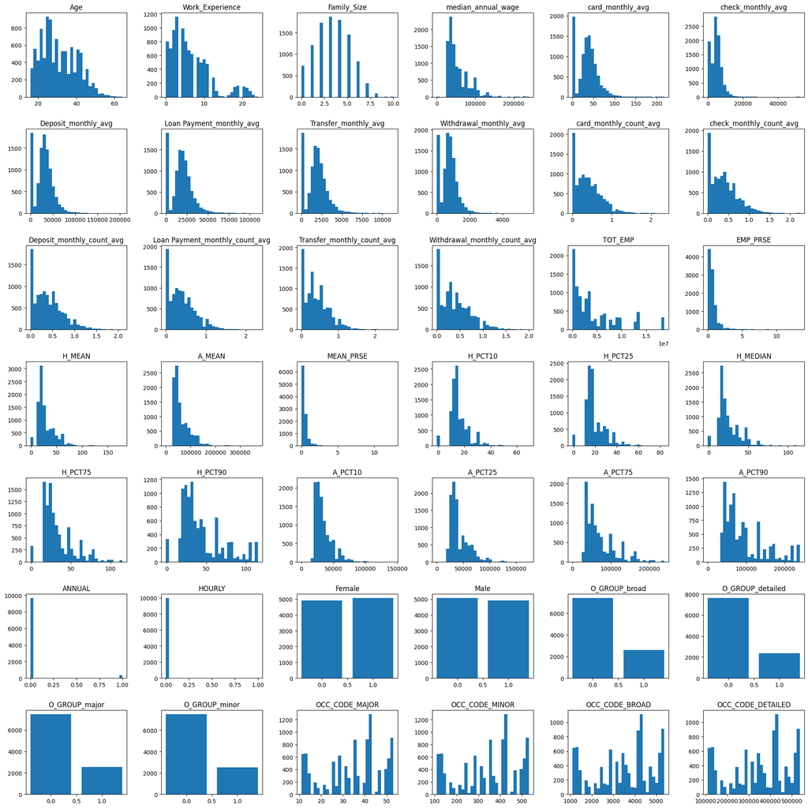

```python
# plot the distribution of the columns
fig, ax = plt.subplots(7, 6, figsize=(20, 20))
for i, column in enumerate(X.columns):
    if X[column].dtype in ['int64','float64','int32']:
        ax[i//6, i%6].hist(X[column], bins=30)
        ax[i//6, i%6].set_title(column)
    if X[column].dtype == 'bool':
        ax[i//6, i%6].bar(X[column].value_counts().index, X[column].value_counts())
        ax[i//6, i%6].set_title(column)
plt.tight_layout()
plt.show()
```

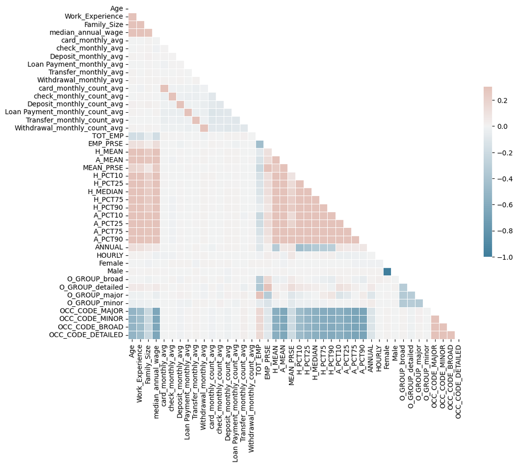

```python
# plot correlation matrix
corr = X.corr()
# Generate a mask for the upper triangle
mask = np.triu(np.ones_like(corr, dtype=bool))
f, ax = plt.subplots(figsize=(11, 9))
cmap = sns.diverging_palette(230, 20, as_cmap=True)
sns.heatmap(corr, mask=mask, cmap=cmap, vmax=.3, center=0,
            square=True, linewidths=.5, cbar_kws={"shrink": .5})
plt.show()
```

## Clustering

```python
# normalize the data
scaler = Normalizer()
X_scaled = scaler.fit_transform(X)
```

```python
# PCA
pca = PCA().fit(X_scaled)
# plot in plotly
fig = px.line(x=range(1, len(pca.explained_variance_ratio_)+1), y=np.cumsum(pca.explained_variance_ratio_))
fig.update_layout(title='PCA Explained Variance Ratio')
fig.update_xaxes(title_text='Number of Components')
fig.update_yaxes(title_text='Cumulative Explained Variance Ratio')
fig.show()
```

### 6 components are enough to explain 90% of the variance

```python
# run PCA with 6 components
pca = PCA(n_components=6)
X_pca = pca.fit_transform(X_scaled)
X_pca = pd.DataFrame(X_pca, columns=[f'PCA_{i}' for i in range(1, 7)])
X_pca
```

|  | PCA_1 | PCA_2 | PCA_3 | PCA_4 | PCA_5 | PCA_6 |
| --- | --- | --- | --- | --- | --- | --- |
| 0 | -0.186668 | -0.036281 | 0.003886 | 0.003439 | -0.000931 | 0.002973 |
| 1 | 0.509279 | -0.141181 | -0.088198 | -0.053296 | 0.025395 | -0.002571 |
| 2 | -0.149054 | -0.059192 | -0.012947 | -0.002327 | 0.001250 | 0.002508 |
| 3 | -0.246064 | -0.013151 | 0.038127 | -0.004412 | -0.001625 | 0.002904 |
| 4 | 1.050010 | -0.246385 | 0.280429 | -0.012768 | -0.010009 | -0.001627 |
| ... | ... | ... | ... | ... | ... | ... |
| 9995 | -0.149804 | -0.059722 | -0.012126 | -0.012258 | -0.000205 | 0.003180 |
| 9996 | -0.271790 | -0.001470 | 0.054431 | 0.001699 | 0.000426 | -0.001673 |
| 9997 | -0.254534 | -0.012887 | 0.043723 | 0.002307 | 0.000994 | 0.000480 |
| 9998 | -0.135570 | 0.140765 | -0.034016 | -0.006311 | 0.003800 | 0.008095 |
| 9999 | -0.165329 | 0.090817 | -0.019607 | 0.016129 | 0.000693 | 0.002345 |

10000 rows × 6 columns

### k-means clustering

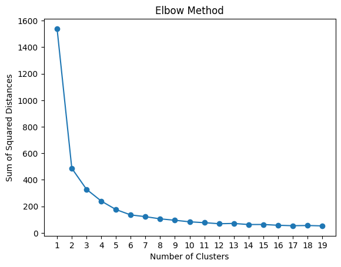

```python
# Apply Elbow Method to find the optimal number of clusters
sum_of_squared_distances = []
for i in range(1, 20):
    kmeans = KMeans(n_clusters=i, random_state=0, init='random', n_init='auto')
    kmeans.fit(X_pca)
    sum_of_squared_distances.append(kmeans.inertia_)
plt.plot(range(1,20), sum_of_squared_distances, marker='o')
plt.title('Elbow Method')
plt.xlabel('Number of Clusters')
plt.xticks(np.arange(1, 20, 1))
plt.ylabel('Sum of Squared Distances')
plt.show()
```

### Hyperparameter tuning by grid search

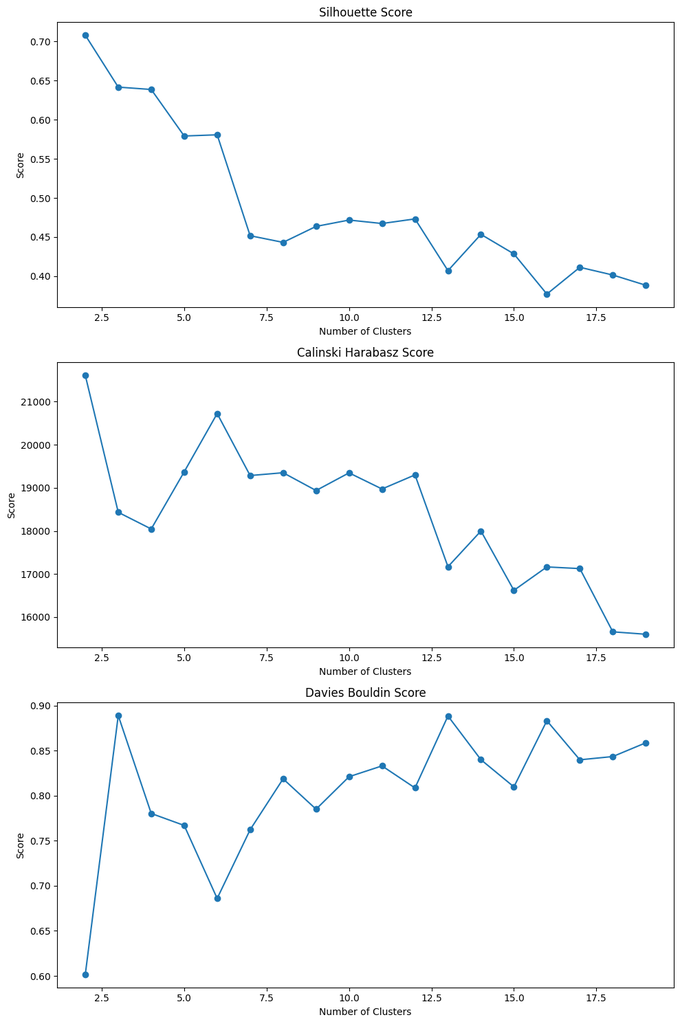

```python
# hyperparameter tuning
silhouette_scores = []
calinski_harabasz_scores = []
davies_bouldin_scores = []

def kmeans_score(n_clusters, X_scaled):
    kmeans = KMeans(n_clusters=n_clusters, random_state=0, init='random', n_init='auto')
    kmeans.fit(X_scaled)
    clusters = kmeans.predict(X_scaled)
    silhouette_score_value = silhouette_score(X_scaled, clusters)
    calinski_harabasz_score_value = calinski_harabasz_score(X_scaled, clusters)
    davies_bouldin_score_value = davies_bouldin_score(X_scaled, clusters)
    return silhouette_score_value, calinski_harabasz_score_value, davies_bouldin_score_value

for n_clusters in range(2, 20):
    silhouette_score_value, calinski_harabasz_score_value, davies_bouldin_score_value = kmeans_score(n_clusters, X_pca)
    silhouette_scores.append(silhouette_score_value)
    calinski_harabasz_scores.append(calinski_harabasz_score_value)
    davies_bouldin_scores.append(davies_bouldin_score_value)

# plot the scores in three subplots
fig, ax = plt.subplots(3, 1, figsize=(10, 15))
ax[0].plot(range(2, 20), silhouette_scores, marker='o')
ax[0].set_title('Silhouette Score')
ax[0].set_xlabel('Number of Clusters')
ax[0].set_ylabel('Score')
ax[1].plot(range(2, 20), calinski_harabasz_scores, marker='o')
ax[1].set_title('Calinski Harabasz Score')
ax[1].set_xlabel('Number of Clusters')
ax[1].set_ylabel('Score')
ax[2].plot(range(2, 20), davies_bouldin_scores, marker='o')
ax[2].set_title('Davies Bouldin Score')
ax[2].set_xlabel('Number of Clusters')
ax[2].set_ylabel('Score')
plt.tight_layout()
plt.show()
```

The three score also shows that the optimal number of clusters is 2.

#### Bayesian Optimization for Hyperparameter Tuning

```python
def hyperparameter_tuning(X, model_name, param_space, conf_dict):
    warnings.filterwarnings('ignore')

    @scheduler.parallel(n_jobs=12)
    def model_score(**params):
        clusters = model_name(X, **params)
        # check the number of clusters
        if len(np.unique(clusters)) == 1:
            return 0
        # silhouette_score is between -1 and 1, the higher the better
        silhouette_score_value = silhouette_score(X, clusters)
        # normalize to 0-1
        silhouette_score_value = (silhouette_score_value + 1) / 2

        # calinski_harabasz_score is a index to evaluate the model, the higher the better, from 0 to +inf
        calinski_harabasz_score_value = calinski_harabasz_score(X, clusters)
        # normalize to 0-1
        calinski_harabasz_score_value = 1 - (1 / (1 + calinski_harabasz_score_value))

        # davies_bouldin_score is a index to evaluate the model, the lower the better, from 0 to 1
        davies_bouldin_score_value = 1 - davies_bouldin_score(X, clusters)


        # comprehensive score is the distance of the score to the best score, the lower the better, transform to higher the better and normalize to 0-1
        comprehensive = (math.sqrt(3) - math.dist([silhouette_score_value, calinski_harabasz_score_value, davies_bouldin_score_value], [1, 1, 1])) / math.sqrt(3)

        return comprehensive

    tuner = Tuner(param_space, model_score, conf_dict)
    results = tuner.maximize()

    cluster_result = model_name(X, **results['best_params'])
    warnings.filterwarnings('default')
    return results, cluster_result
```

```python
def cluster_plot(X, clusters, method = 'tsne'):
    # make clusters as a string
    clusters_plot = clusters.astype(str)
    if method == 'tsne':
        tsne = TSNE(n_components=3, random_state=0, n_jobs=-2)
        plot_data = tsne.fit_transform(X)
        plot_data = pd.DataFrame(plot_data, columns=['x', 'y', 'z'])
        plot_data['cluster'] = clusters_plot
    if method == 'pca':
        pca = PCA(n_components=3)
        plot_data = pca.fit_transform(X)
        plot_data = pd.DataFrame(plot_data, columns=['x', 'y', 'z'])
        plot_data['cluster'] = clusters_plot
    fig = px.scatter_3d(plot_data, x='x', y='y', z='z', color='cluster', color_discrete_sequence=px.colors.qualitative.Set1)
    fig.update_traces(marker=dict(size=2))
    fig.update_layout(height=800)
    return fig
```

```python
# Apply Bayesian Optimization to find the optimal number of clusters and hyperparameters
conf_dict = dict(num_iteration=40, domain_size=10000, initial_random=3)
param_space = {'n_clusters': range(2, 100), 'init': ['k-means++', 'random'], 'max_iter': range(100, 1000),'algorithm': ['lloyd', 'elkan']}

def kmean_clusters(X, **params):
    model = KMeans(**params)
    model.fit(X)
    clusters = model.predict(X)
    return clusters

kmean_results, kmean_cluster_result = hyperparameter_tuning(X_pca, kmean_clusters, param_space, conf_dict)


print('best parameters:', kmean_results['best_params'])
print('best accuracy:', kmean_results['best_objective'])
print('Silhouette Score:', silhouette_score(X_pca, kmean_cluster_result))
print('Calinski Harabasz Score:', calinski_harabasz_score(X_pca, kmean_cluster_result))
print('Davies Bouldin Score:', davies_bouldin_score(X_pca, kmean_cluster_result))
```

```
best parameters: {'algorithm': 'lloyd', 'init': 'random', 'max_iter': 846, 'n_clusters': 2}
best accuracy: 0.6425655038115965
Silhouette Score: 0.708174092678777
Calinski Harabasz Score: 21611.258750327295
Davies Bouldin Score: 0.601654107448369
```

```python
# plot the clusters with tsne
fig1 = cluster_plot(X_scaled, kmean_cluster_result)
fig1.show()
```

```python
# print the number of customers in each cluster
for cluster in np.unique(kmean_cluster_result):
    print(f'Number of Customers in Cluster {cluster}: {len(kmean_cluster_result[kmean_cluster_result == cluster])}')
```

```
Number of Customers in Cluster 0: 7866
Number of Customers in Cluster 1: 2134
```

```python
# Get the average values of each column for each cluster
kmean_cluster_df = pd.DataFrame(X_scaled)
kmean_cluster_df.columns = X.columns
kmean_cluster_df['Cluster'] = kmean_cluster_result
kmean_cluster_df = kmean_cluster_df.groupby('Cluster').mean()
kmean_cluster_df
```

| Cluster | Age | Work_Experience | Family_Size | median_annual_wage | card_monthly_avg | check_monthly_avg | Deposit_monthly_avg | Loan Payment_monthly_avg | Transfer_monthly_avg | Withdrawal_monthly_avg | ... | Female | Male | O_GROUP_broad | O_GROUP_detailed | O_GROUP_major | O_GROUP_minor | OCC_CODE_MAJOR | OCC_CODE_MINOR | OCC_CODE_BROAD | OCC_CODE_DETAILED |
| --- | --- | --- | --- | --- | --- | --- | --- | --- | --- | --- | --- | --- | --- | --- | --- | --- | --- | --- | --- | --- | --- |
| 0 | 0.000013 | 0.000003 | 0.000001 | 0.024365 | 0.000015 | 0.001912 | 0.012555 | 0.007576 | 0.000778 | 0.000307 | ... | 2.078130e-07 | 2.073791e-07 | 1.404948e-07 | 1.222999e-07 | 4.621482e-08 | 1.061825e-07 | 0.000013 | 0.000127 | 0.001276 | 0.127633 |
| 1 | 0.000069 | 0.000015 | 0.000007 | 0.127889 | 0.000075 | 0.009659 | 0.061567 | 0.038103 | 0.003910 | 0.001497 | ... | 1.070511e-06 | 1.014810e-06 | 8.144815e-07 | 1.076611e-06 | 7.168435e-09 | 1.870593e-07 | 0.000068 | 0.000682 | 0.006896 | 0.689659 |

2 rows × 42 columns

```python
# sort columns by variance
kmean_cluster_df = kmean_cluster_df.reindex(kmean_cluster_df.var().sort_values(ascending=False).index, axis=1)
kmean_cluster_df.head()
```

| Cluster | OCC_CODE_DETAILED | TOT_EMP | A_PCT90 | A_PCT75 | A_MEAN | median_annual_wage | A_PCT25 | A_PCT10 | Deposit_monthly_avg | Loan Payment_monthly_avg | ... | Transfer_monthly_count_avg | Deposit_monthly_count_avg | card_monthly_count_avg | check_monthly_count_avg | Withdrawal_monthly_count_avg | Loan Payment_monthly_count_avg | O_GROUP_minor | ANNUAL | O_GROUP_major | HOURLY |
| --- | --- | --- | --- | --- | --- | --- | --- | --- | --- | --- | --- | --- | --- | --- | --- | --- | --- | --- | --- | --- | --- |
| 0 | 0.127633 | 0.977863 | 0.041909 | 0.032252 | 0.027330 | 0.024365 | 0.018769 | 0.015011 | 0.012555 | 0.007576 | ... | 1.626724e-07 | 1.660553e-07 | 1.597458e-07 | 1.617669e-07 | 1.671209e-07 | 1.651102e-07 | 1.061825e-07 | 2.159960e-08 | 4.621482e-08 | 0.000000e+00 |
| 1 | 0.689659 | 0.500208 | 0.207847 | 0.164492 | 0.141576 | 0.127889 | 0.099711 | 0.080394 | 0.061567 | 0.038103 | ... | 8.304310e-07 | 8.297718e-07 | 8.191080e-07 | 8.196751e-07 | 8.192499e-07 | 8.002999e-07 | 1.870593e-07 | 8.928642e-08 | 7.168435e-09 | 3.362797e-09 |

2 rows × 42 columns

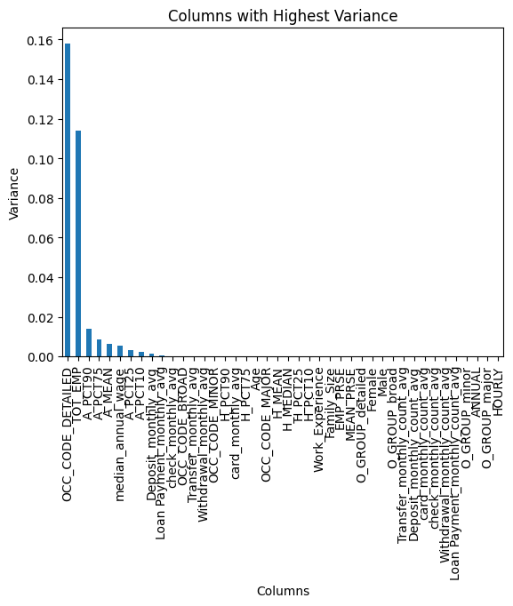

```python
# Get top 10 columns with the highest variance and use bar plot to show the variance
top_10_columns = kmean_cluster_df.var().sort_values(ascending=False)
top_10_columns.plot(kind='bar')
plt.title('Columns with Highest Variance')
plt.ylabel('Variance')
plt.xlabel('Columns')
plt.show()
```

The top 10 columns that have the highest feature importance are mostly demographic information and with average of average of desposit and loan payment amount of 30-day rolling window.

### HDBSCAN clustering

```python
# Apply Bayesian Optimization to find the optimal number of clusters and hyperparameters
conf_dict = dict(num_iteration=40, domain_size=10000, initial_random=3)
param_space = {
    'min_cluster_size': range(2, 50),
    'min_samples': range(2, 50),
    'max_cluster_size': range(50, len(X_scaled), 100),
    'metric': ['manhattan', 'euclidean', 'hamming'],
    'leaf_size': range(10, 100),
    'cluster_selection_method': ['eom', 'leaf']
}

def hdb_scan_clusters(X, **params):
    model = HDBSCAN(**params)
    model.fit(X)
    clusters = model.fit_predict(X)
    return clusters

hdbscan_result, hdbscan_cluster_result = hyperparameter_tuning(X_pca, hdb_scan_clusters, param_space, conf_dict)

print('best parameters:', hdbscan_result['best_params'])
print('best accuracy:', hdbscan_result['best_objective'])
print('Silhouette Score:', silhouette_score(X_pca, hdbscan_cluster_result))
print('Calinski Harabasz Score:', calinski_harabasz_score(X_pca, hdbscan_cluster_result))
print('Davies Bouldin Score:', davies_bouldin_score(X_pca, hdbscan_cluster_result))
print('Number of Clusters:', len(np.unique(hdbscan_cluster_result)))
```

```
best parameters: {'cluster_selection_method': 'eom', 'leaf_size': 82, 'max_cluster_size': 5650, 'metric': 'euclidean', 'min_cluster_size': 45, 'min_samples': 40}
best accuracy: 0.4083019161779855
Silhouette Score: 0.14080266086728108
Calinski Harabasz Score: 297.6289092294178
Davies Bouldin Score: 0.9304588313992345
Number of Clusters: 43
```

```python
# plot the clusters with tsne
cluster_plot(X_scaled, hdbscan_cluster_result).show()
```

```python
# print the number of customers in each cluster
for cluster in np.unique(hdbscan_cluster_result):
    print(f'Number of Customers in Cluster {cluster}: {len(hdbscan_cluster_result[hdbscan_cluster_result == cluster])}')
```

```
Number of Customers in Cluster -1: 3140
Number of Customers in Cluster 0: 71
Number of Customers in Cluster 1: 47
Number of Customers in Cluster 2: 291
Number of Customers in Cluster 3: 348
Number of Customers in Cluster 4: 93
Number of Customers in Cluster 5: 92
Number of Customers in Cluster 6: 54
Number of Customers in Cluster 7: 47
Number of Customers in Cluster 8: 95
Number of Customers in Cluster 9: 224
Number of Customers in Cluster 10: 49
Number of Customers in Cluster 11: 179
Number of Customers in Cluster 12: 57
Number of Customers in Cluster 13: 107
Number of Customers in Cluster 14: 315
Number of Customers in Cluster 15: 130
Number of Customers in Cluster 16: 141
Number of Customers in Cluster 17: 200
Number of Customers in Cluster 18: 167
Number of Customers in Cluster 19: 102
Number of Customers in Cluster 20: 145
Number of Customers in Cluster 21: 107
Number of Customers in Cluster 22: 85
Number of Customers in Cluster 23: 90
Number of Customers in Cluster 24: 522
Number of Customers in Cluster 25: 278
Number of Customers in Cluster 26: 119
Number of Customers in Cluster 27: 157
Number of Customers in Cluster 28: 94
Number of Customers in Cluster 29: 218
Number of Customers in Cluster 30: 255
Number of Customers in Cluster 31: 205
Number of Customers in Cluster 32: 326
Number of Customers in Cluster 33: 382
Number of Customers in Cluster 34: 146
Number of Customers in Cluster 35: 84
Number of Customers in Cluster 36: 292
Number of Customers in Cluster 37: 84
Number of Customers in Cluster 38: 53
Number of Customers in Cluster 39: 113
Number of Customers in Cluster 40: 210
Number of Customers in Cluster 41: 86
```

```python
# Get the average values of each column for each cluster
hdbscan_cluster_df = pd.DataFrame(X_scaled)
hdbscan_cluster_df.columns = X.columns
hdbscan_cluster_df['cluster'] = hdbscan_cluster_result
hdbscan_cluster_df = hdbscan_cluster_df.groupby('cluster').mean()
hdbscan_cluster_df.head()
```

| cluster | Age | Work_Experience | Family_Size | median_annual_wage | card_monthly_avg | check_monthly_avg | Deposit_monthly_avg | Loan Payment_monthly_avg | Transfer_monthly_avg | Withdrawal_monthly_avg | ... | Female | Male | O_GROUP_broad | O_GROUP_detailed | O_GROUP_major | O_GROUP_minor | OCC_CODE_MAJOR | OCC_CODE_MINOR | OCC_CODE_BROAD | OCC_CODE_DETAILED |
| --- | --- | --- | --- | --- | --- | --- | --- | --- | --- | --- | --- | --- | --- | --- | --- | --- | --- | --- | --- | --- | --- |
| -1 | 0.000057 | 0.000013 | 0.000006 | 0.107255 | 0.000059 | 0.007658 | 0.050027 | 0.030344 | 0.003108 | 0.001196 | ... | 8.463314e-07 | 8.090294e-07 | 6.427708e-07 | 8.251100e-07 | 7.704908e-09 | 1.797750e-07 | 0.000049 | 0.000489 | 0.004944 | 0.494469 |
| 0 | 0.000049 | 0.000007 | 0.000006 | 0.084425 | 0.000073 | 0.009332 | 0.060544 | 0.035446 | 0.003620 | 0.001364 | ... | 1.066295e-06 | 8.498479e-07 | 9.410972e-07 | 8.953553e-07 | 0.000000e+00 | 7.969021e-08 | 0.000089 | 0.000889 | 0.008994 | 0.899431 |
| 1 | 0.000046 | 0.000007 | 0.000005 | 0.062251 | 0.000070 | 0.007683 | 0.055327 | 0.031375 | 0.004084 | 0.001634 | ... | 7.743199e-07 | 1.006216e-06 | 7.965920e-07 | 7.739406e-07 | 0.000000e+00 | 2.100035e-07 | 0.000079 | 0.000792 | 0.008004 | 0.800469 |
| 2 | 0.000039 | 0.000007 | 0.000004 | 0.057147 | 0.000048 | 0.006192 | 0.039442 | 0.024908 | 0.002477 | 0.001000 | ... | 6.212874e-07 | 7.107017e-07 | 7.025794e-07 | 4.730825e-07 | 0.000000e+00 | 1.563273e-07 | 0.000059 | 0.000590 | 0.005956 | 0.595598 |
| 3 | 0.000031 | 0.000009 | 0.000003 | 0.065156 | 0.000027 | 0.003577 | 0.021516 | 0.013476 | 0.001421 | 0.000570 | ... | 3.834517e-07 | 3.816974e-07 | 2.883875e-07 | 2.310840e-07 | 1.051979e-07 | 1.404796e-07 | 0.000012 | 0.000119 | 0.001192 | 0.119261 |

5 rows × 42 columns

```python
# sort columns by variance
hdbscan_cluster_df = hdbscan_cluster_df.reindex(hdbscan_cluster_df.var().sort_values(ascending=False).index, axis=1)
hdbscan_cluster_df.head()
```

| cluster | OCC_CODE_DETAILED | TOT_EMP | A_PCT90 | A_PCT75 | A_MEAN | median_annual_wage | A_PCT25 | A_PCT10 | Deposit_monthly_avg | Loan Payment_monthly_avg | ... | Deposit_monthly_count_avg | Withdrawal_monthly_count_avg | Transfer_monthly_count_avg | Loan Payment_monthly_count_avg | check_monthly_count_avg | card_monthly_count_avg | O_GROUP_minor | O_GROUP_major | ANNUAL | HOURLY |
| --- | --- | --- | --- | --- | --- | --- | --- | --- | --- | --- | --- | --- | --- | --- | --- | --- | --- | --- | --- | --- | --- |
| -1 | 0.494469 | 0.669042 | 0.177381 | 0.139651 | 0.119446 | 0.107255 | 0.082845 | 0.066243 | 0.050027 | 0.030344 | ... | 6.474246e-07 | 6.603843e-07 | 6.559268e-07 | 6.310696e-07 | 6.514199e-07 | 6.504988e-07 | 1.797750e-07 | 7.704908e-09 | 9.777438e-08 | 2.285417e-09 |
| 0 | 0.899431 | 0.359864 | 0.123578 | 0.101845 | 0.089096 | 0.084425 | 0.070289 | 0.060052 | 0.060544 | 0.035446 | ... | 9.275937e-07 | 7.534350e-07 | 7.502600e-07 | 7.717010e-07 | 6.842752e-07 | 7.566958e-07 | 7.969021e-08 | 0.000000e+00 | 0.000000e+00 | 0.000000e+00 |
| 1 | 0.800469 | 0.571248 | 0.090351 | 0.074224 | 0.066223 | 0.062251 | 0.053468 | 0.045980 | 0.055327 | 0.031375 | ... | 8.640704e-07 | 7.699660e-07 | 7.601528e-07 | 6.531000e-07 | 7.626200e-07 | 6.703096e-07 | 2.100035e-07 | 0.000000e+00 | 0.000000e+00 | 0.000000e+00 |
| 2 | 0.595598 | 0.782093 | 0.089650 | 0.071556 | 0.061682 | 0.057147 | 0.046621 | 0.039090 | 0.039442 | 0.024908 | ... | 5.886492e-07 | 5.158647e-07 | 5.215348e-07 | 5.950913e-07 | 5.400572e-07 | 4.652227e-07 | 1.563273e-07 | 0.000000e+00 | 0.000000e+00 | 0.000000e+00 |
| 3 | 0.119261 | 0.972679 | 0.118749 | 0.089602 | 0.073705 | 0.065156 | 0.048154 | 0.036886 | 0.021516 | 0.013476 | ... | 3.013205e-07 | 3.070342e-07 | 2.696240e-07 | 3.026448e-07 | 2.790032e-07 | 3.149999e-07 | 1.404796e-07 | 1.051979e-07 | 5.846159e-08 | 0.000000e+00 |

5 rows × 42 columns

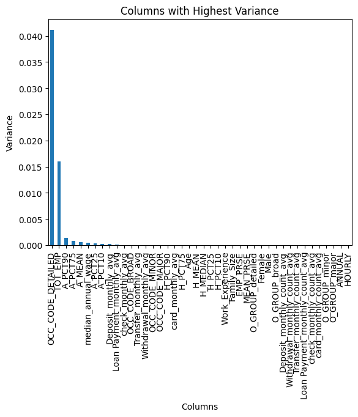

```python
# Get top 10 columns with the highest variance and use bar plot to show the variance
top_10_columns = hdbscan_cluster_df.var().sort_values(ascending=False)
top_10_columns.plot(kind='bar')
plt.title('Columns with Highest Variance')
plt.ylabel('Variance')
plt.xlabel('Columns')
plt.show()
```

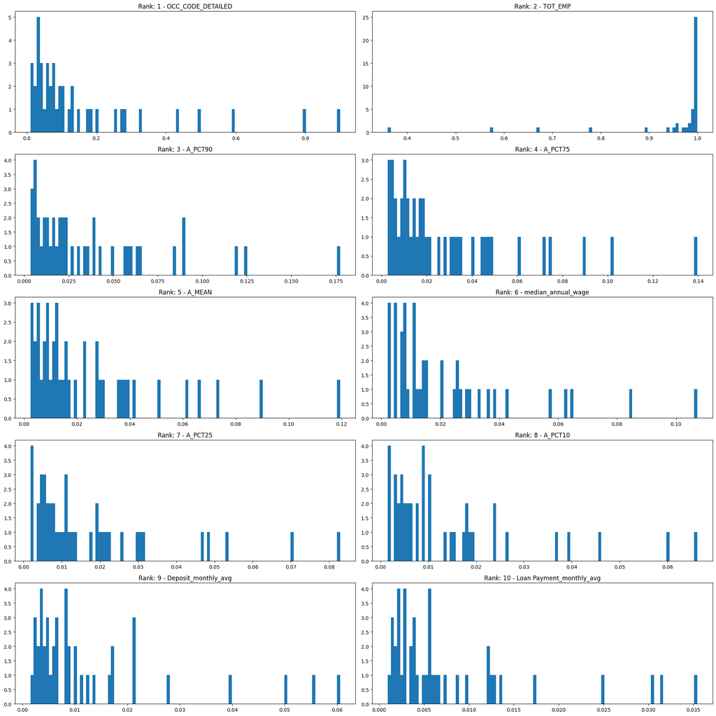

```python
# plot the distribution of the top 10 columns with the highest variance
fig, ax = plt.subplots(5, 2, figsize=(20, 20))
for i, column in enumerate(top_10_columns.index[:10]):
    ax[i//2, i%2].hist(hdbscan_cluster_df[column], bins=100)
    ax[i//2, i%2].set_title(f'Rank: {i+1} - {column}')
plt.tight_layout()
plt.show()
```

### OPTICS clustering

```python
# Apply Bayesian Optimization to find the optimal number of clusters and hyperparameters
conf_dict = dict(num_iteration=40, domain_size=10000, initial_random=3)

param_space = {
    'min_samples': range(2, 50),
    #'max_eps': np.linspace(0.1, 1, 10),
    'metric': ['manhattan', 'euclidean', 'hamming'],
    'p': range(1, 5),
    'cluster_method': ['xi', 'dbscan'],
    'xi': np.linspace(0.01, 1, 100),
    'predecessor_correction': [True, False],
    'min_cluster_size': range(2, 50),
    'leaf_size': range(10, 100),
}

def optics_cluster(X, **params):
    model = OPTICS(**params)
    model.fit(X)
    clusters = model.fit_predict(X)
    return clusters

optics_result, optics_cluster_result = hyperparameter_tuning(X_pca, optics_cluster, param_space, conf_dict)

print('best parameters:', optics_result['best_params'])
print('best accuracy:', optics_result['best_objective'])
print('Silhouette Score:', silhouette_score(X_pca, optics_cluster_result))
print('Calinski Harabasz Score:', calinski_harabasz_score(X_pca, optics_cluster_result))
print('Davies Bouldin Score:', davies_bouldin_score(X_pca, optics_cluster_result))
print('Number of Clusters:', len(np.unique(optics_cluster_result)))
```

```
best parameters: {'cluster_method': 'xi', 'leaf_size': 74, 'metric': 'manhattan', 'min_cluster_size': 34, 'min_samples': 45, 'p': 3, 'predecessor_correction': True, 'xi': 0.17}
best accuracy: 0.3771243354022924
Silhouette Score: -0.011561869203672253
Calinski Harabasz Score: 136.2918848934021
Davies Bouldin Score: 0.9529191328746471
Number of Clusters: 25
```

```python
# plot the clusters with tsne
fig1 = cluster_plot(X_scaled, optics_cluster_result)
fig1.show()
```

```python
# print the number data points in each cluster
print('Number of Data Points in Each Cluster:')
for cluster in np.unique(optics_cluster_result):
    print(f'Cluster {cluster}: {len(optics_cluster_result[optics_cluster_result == cluster])}')
```

```
Number of Data Points in Each Cluster:
Cluster -1: 6415
Cluster 0: 90
Cluster 1: 121
Cluster 2: 89
Cluster 3: 193
Cluster 4: 146
Cluster 5: 95
Cluster 6: 388
Cluster 7: 99
Cluster 8: 218
Cluster 9: 256
Cluster 10: 207
Cluster 11: 327
Cluster 12: 119
Cluster 13: 157
Cluster 14: 102
Cluster 15: 145
Cluster 16: 167
Cluster 17: 58
Cluster 18: 107
Cluster 19: 179
Cluster 20: 51
Cluster 21: 167
Cluster 22: 56
Cluster 23: 48
```

```python
# Get the average values of each column for each cluster
optics_cluster_df = pd.DataFrame(X_scaled)
optics_cluster_df.columns = X.columns
optics_cluster_df['cluster'] = optics_cluster_result
optics_cluster_df = optics_cluster_df.groupby('cluster').mean()
optics_cluster_df.head()
```

| cluster | Age | Work_Experience | Family_Size | median_annual_wage | card_monthly_avg | check_monthly_avg | Deposit_monthly_avg | Loan Payment_monthly_avg | Transfer_monthly_avg | Withdrawal_monthly_avg | ... | Female | Male | O_GROUP_broad | O_GROUP_detailed | O_GROUP_major | O_GROUP_minor | OCC_CODE_MAJOR | OCC_CODE_MINOR | OCC_CODE_BROAD | OCC_CODE_DETAILED |
| --- | --- | --- | --- | --- | --- | --- | --- | --- | --- | --- | --- | --- | --- | --- | --- | --- | --- | --- | --- | --- | --- |
| -1 | 0.000037 | 8.125712e-06 | 3.833204e-06 | 0.067125 | 0.000040 | 0.005174 | 0.033405 | 0.020464 | 0.002102 | 0.000815 | ... | 5.696426e-07 | 5.509824e-07 | 4.346122e-07 | 5.025161e-07 | 2.505784e-08 | 1.584388e-07 | 0.000036 | 0.000358 | 0.003615 | 0.361524 |
| 0 | 0.000005 | 7.322703e-07 | 6.759429e-07 | 0.010873 | 0.000008 | 0.000980 | 0.006054 | 0.003926 | 0.000460 | 0.000185 | ... | 1.249024e-07 | 9.551391e-08 | 0.000000e+00 | 0.000000e+00 | 0.000000e+00 | 2.204163e-07 | 0.000010 | 0.000104 | 0.001040 | 0.104036 |
| 1 | 0.000013 | 3.185838e-06 | 1.308518e-06 | 0.026244 | 0.000012 | 0.001616 | 0.009181 | 0.005869 | 0.000689 | 0.000233 | ... | 1.335218e-07 | 1.896022e-07 | 1.655685e-07 | 1.575554e-07 | 0.000000e+00 | 0.000000e+00 | 0.000009 | 0.000094 | 0.000941 | 0.094074 |
| 2 | 0.000007 | 1.773221e-06 | 6.709479e-07 | 0.008296 | 0.000005 | 0.000841 | 0.004924 | 0.002955 | 0.000288 | 0.000117 | ... | 8.663378e-08 | 7.741677e-08 | 0.000000e+00 | 0.000000e+00 | 1.640505e-07 | 0.000000e+00 | 0.000008 | 0.000077 | 0.000771 | 0.077104 |
| 3 | 0.000004 | 5.207409e-07 | 4.441675e-07 | 0.005674 | 0.000006 | 0.000777 | 0.004430 | 0.003221 | 0.000287 | 0.000109 | ... | 7.933147e-08 | 7.841160e-08 | 9.060555e-08 | 0.000000e+00 | 0.000000e+00 | 6.713751e-08 | 0.000008 | 0.000077 | 0.000778 | 0.077798 |

5 rows × 42 columns

```python
# sort columns by variance
optics_cluster_df = optics_cluster_df.reindex(optics_cluster_df.var().sort_values(ascending=False).index, axis=1)
optics_cluster_df.head()
```

| cluster | OCC_CODE_DETAILED | TOT_EMP | A_PCT90 | A_PCT75 | A_MEAN | median_annual_wage | A_PCT25 | A_PCT10 | Deposit_monthly_avg | Loan Payment_monthly_avg | ... | O_GROUP_broad | O_GROUP_major | Deposit_monthly_count_avg | Loan Payment_monthly_count_avg | Withdrawal_monthly_count_avg | check_monthly_count_avg | Transfer_monthly_count_avg | card_monthly_count_avg | ANNUAL | HOURLY |
| --- | --- | --- | --- | --- | --- | --- | --- | --- | --- | --- | --- | --- | --- | --- | --- | --- | --- | --- | --- | --- | --- |
| -1 | 0.361524 | 0.807699 | 0.110770 | 0.087074 | 0.074506 | 0.067125 | 0.052238 | 0.042038 | 0.033405 | 0.020464 | ... | 4.346122e-07 | 2.505784e-08 | 4.465135e-07 | 4.355317e-07 | 4.453989e-07 | 4.384634e-07 | 4.430019e-07 | 4.365080e-07 | 5.402857e-08 | 1.118661e-09 |
| 0 | 0.104036 | 0.994038 | 0.019463 | 0.014360 | 0.012456 | 0.010873 | 0.008601 | 0.007446 | 0.006054 | 0.003926 | ... | 0.000000e+00 | 0.000000e+00 | 7.846179e-08 | 8.522549e-08 | 8.666375e-08 | 7.725425e-08 | 1.075959e-07 | 9.015125e-08 | 0.000000e+00 | 0.000000e+00 |
| 1 | 0.094074 | 0.992863 | 0.041812 | 0.032668 | 0.028761 | 0.026244 | 0.021546 | 0.019791 | 0.009181 | 0.005869 | ... | 1.655685e-07 | 0.000000e+00 | 1.080760e-07 | 1.412427e-07 | 1.300701e-07 | 1.261449e-07 | 1.205937e-07 | 1.313713e-07 | 0.000000e+00 | 0.000000e+00 |
| 2 | 0.077104 | 0.996692 | 0.015457 | 0.011559 | 0.009581 | 0.008296 | 0.006488 | 0.005599 | 0.004924 | 0.002955 | ... | 0.000000e+00 | 1.640505e-07 | 6.523168e-08 | 5.680420e-08 | 6.497091e-08 | 7.522120e-08 | 6.296556e-08 | 6.703727e-08 | 0.000000e+00 | 0.000000e+00 |
| 3 | 0.077798 | 0.996832 | 0.008277 | 0.006731 | 0.005985 | 0.005674 | 0.004796 | 0.004190 | 0.004430 | 0.003221 | ... | 9.060555e-08 | 0.000000e+00 | 5.924374e-08 | 6.483864e-08 | 6.068065e-08 | 6.591983e-08 | 6.400360e-08 | 5.963396e-08 | 0.000000e+00 | 0.000000e+00 |

5 rows × 42 columns

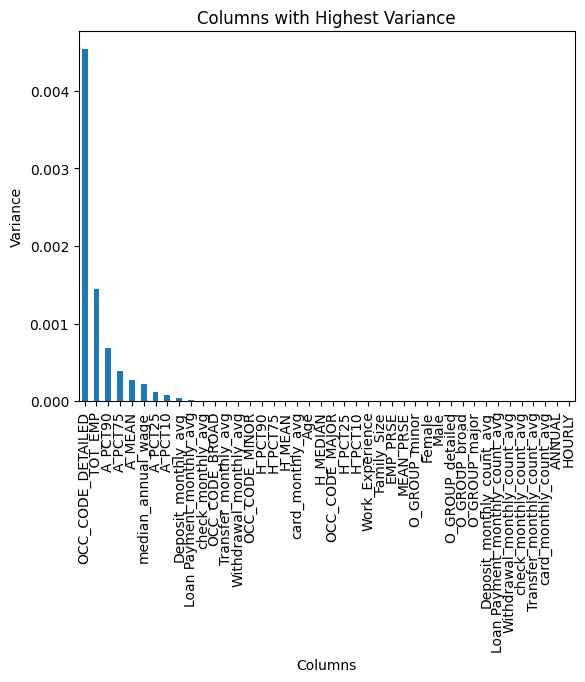

```python
# Get top 10 columns with the highest variance and use bar plot to show the variance
top_10_columns = optics_cluster_df.var().sort_values(ascending=False)
top_10_columns.plot(kind='bar')
plt.title('Columns with Highest Variance')
plt.ylabel('Variance')
plt.xlabel('Columns')
plt.show()
```

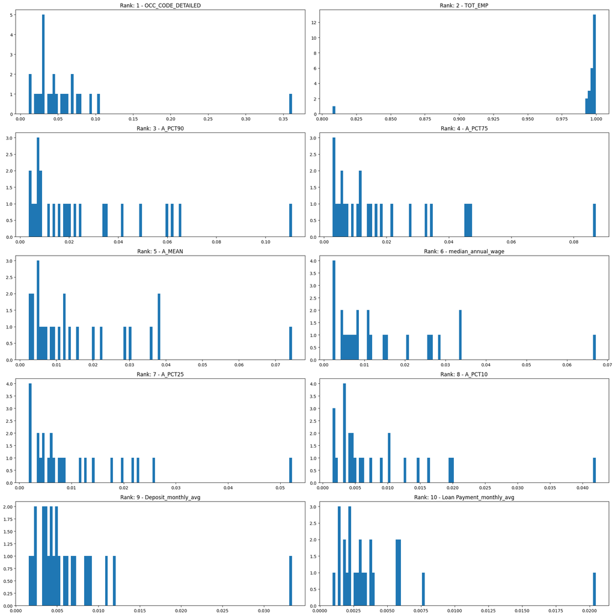

```python
# plot the distribution of the top 10 columns with the highest variance
fig, ax = plt.subplots(5, 2, figsize=(20, 20))
for i, column in enumerate(top_10_columns.index[:10]):
    ax[i//2, i%2].hist(optics_cluster_df[column], bins=100)
    ax[i//2, i%2].set_title(f'Rank: {i+1} - {column}')
plt.tight_layout()
plt.show()
```

## Conclusion

#### Feature Importance

By calculate the variance of each feature in each cluster, the top 10 features are selected. The top 10 features are mostly demographic information and with average of average of desposit and loan payment amount of 30-day rolling window. The feature importance is consistent with the domain knowledge. The feature importance can be used to explain the cluster and help the bank to make decision. The feature engineering can be used to improve the model performance and interpretability.

#### Future Work

For the future step, there are lots of process can be improved to get a better customer segmentation. The first is feature engineering. The feature importance shows that the demographic information is the most important feature. However, the demographic information is not enough to reflect the customer's pattern. The potential of `transaction` table have not been released. It is possible to get the mean and variance of transaction amount for each transaction per transaction type with a 30-day rolling window. Then the abnormal transaction amount which is greater than 3 times of the standard deviation can be detected. Besides feature engineering, the model can be improved by useing the ensemble method. The ensemble method can combine the result of different clustering model and get a better result. The scoring method can be improved by developing a more comprehensive score.